# Analisi del testo di Simpson e Griffin

Caicchiolo Giorgia, Carollo Daniele, Paganelli Gabriele, Pati Riccardo, Tossici Giorgia

2025-06-15

## Introduzione

Le serie animate *I Simpson* e *I Griffin* rappresentano due pilastri della cultura pop televisiva americana, capaci di influenzare intere generazioni con il loro umorismo pungente e i loro riferimenti sociopolitici. Pur condividendo un *format* simile e un *target* in parte sovrapponibile, le due serie si differenziano per stile narrativo, linguaggio, contenuti e approccio ai temi trattati.

Il presente progetto si propone di analizzare in chiave comparativa queste due produzioni al fine di esplorare somiglianze e differenze nei contenuti testuali e concettuali delle loro sceneggiature.

A partire dai testi degli episodi, raccolti tramite *scraping* dal sito *Springfield!Springfield!* e opportunamente ripuliti e preprocessati, l’analisi si articola in più fasi: *text mining*, *topic modeling* e *sentiment analysis*.

Si può trovare in Appendice il codice relativo alle fasi di *web scraping* (Appendice A) e *pre-processing* (Appendice C) ed anche un fallimentare tentativo di pulizia dei dati per mezzo di un *Large Language Model* (Appendice B).

## *Text Mining*

### Analisi delle frequenze ne *I Simpson*

Partendo dalle frequenze calcolate tramite la funzione `elabora_testo` (si veda l’Appendice D: Definizione Funzioni), è possibile esplorare il lessico più utilizzato. L’analisi si concentra inizialmente sulla distribuzione generale delle frequenze, per poi isolare i termini meno informativi — come parole troppo corte — e concludersi con l’identificazione dei termini più ricorrenti. La prima sezione è riservata a *I Simpson* e la seconda a *I Griffin*.

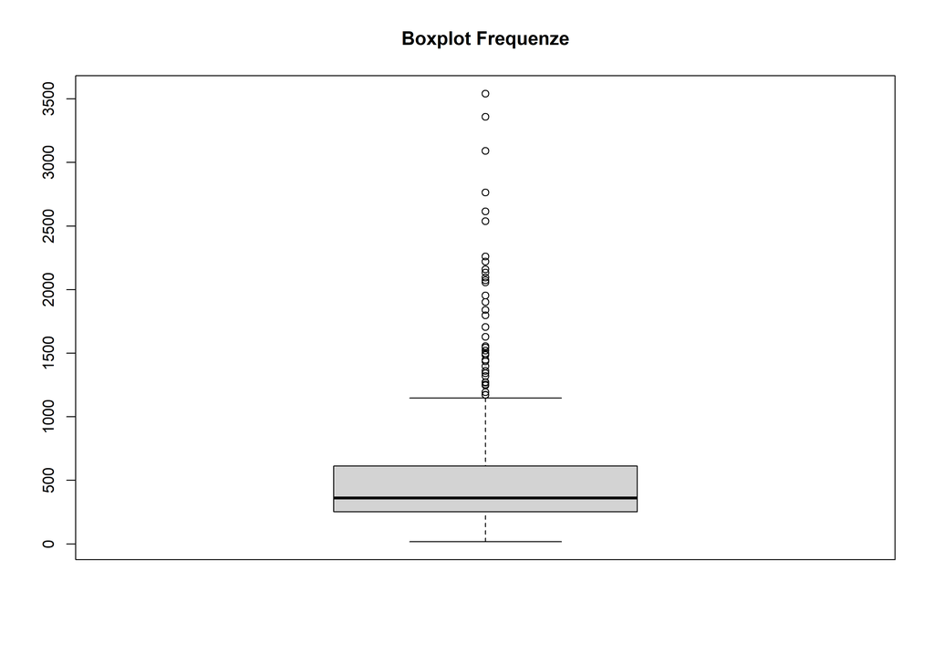

```r
frequenze_simpson %>% select(n) %>% boxplot(main = "Boxplot Frequenze")
```

Successivamente, si indagano le parole più frequenti in termini assoluti. Questo permette di comprendere quali termini dominano il vocabolario della serie, prima della rimozione manuale di alcune parole poco significative.

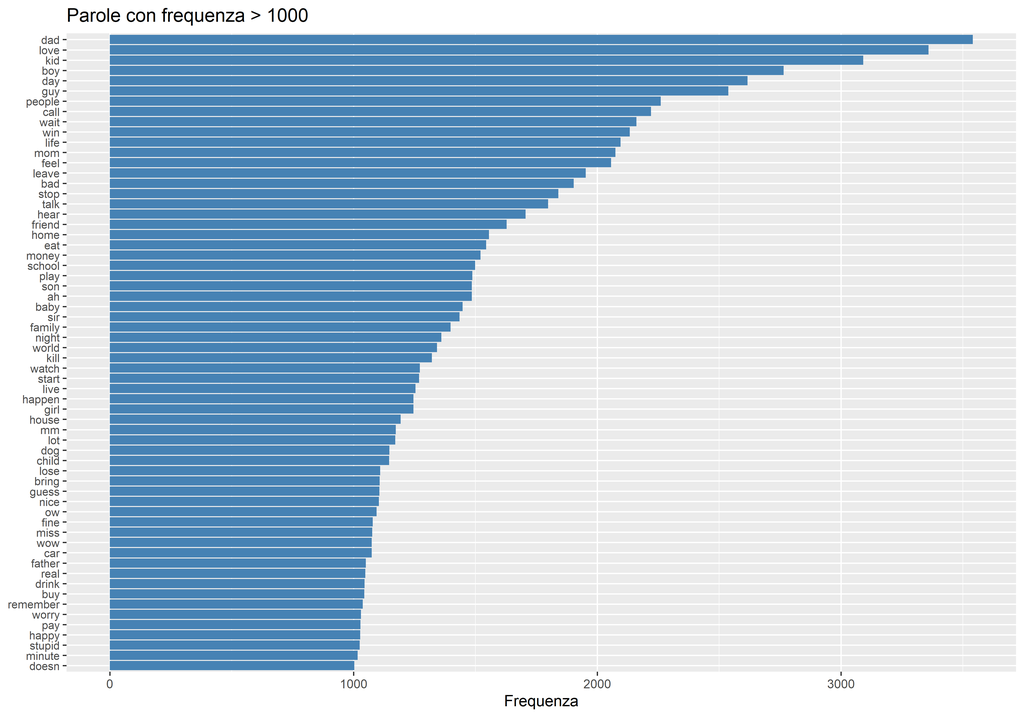

```r
# Parole con frequenza > 1000
frequenze_simpson %>%
  filter(n > 1000) %>%
  mutate(word = reorder(word, n)) %>%
  ggplot(aes(word, n)) +
  geom_col(fill = "steelblue") +
  coord_flip() +
  labs(title = "Parole con frequenza > 1000", x = NULL, y = "Frequenza") +
  theme(axis.text.y = element_text(size = 8))
```

I seguenti grafici mostrano le frequenze assolute delle parole con due o tre caratteri, con l’intento di individuare parole poco informative o addirittura vuote di significato.

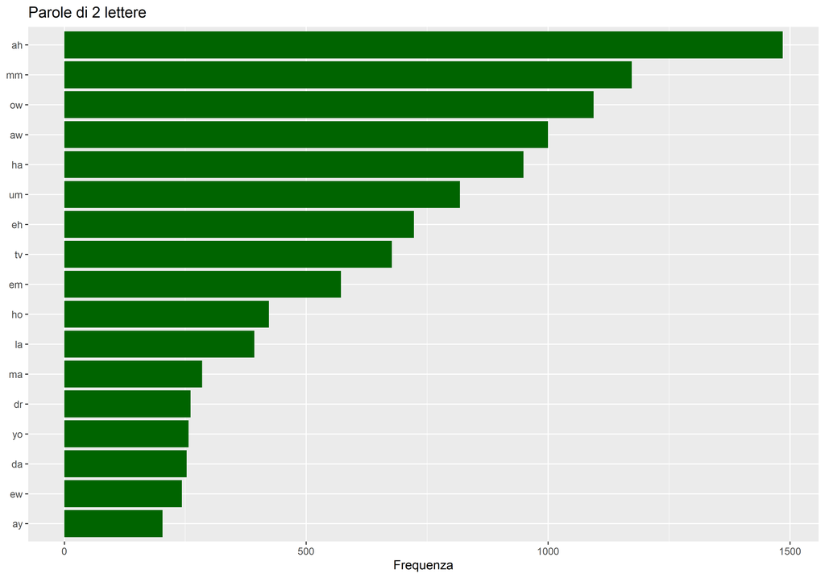

```r
# Parole di due lettere (si tengono solo tv e dr)
frequenze_simpson %>%
  filter(nchar(word) == 2) %>%
  mutate(word = reorder(word, n)) %>%
  ggplot(aes(word, n)) +
  geom_col(fill = "darkgreen") +
  coord_flip() +
  labs(title = "Parole di 2 lettere", x = NULL, y = "Frequenza")
```

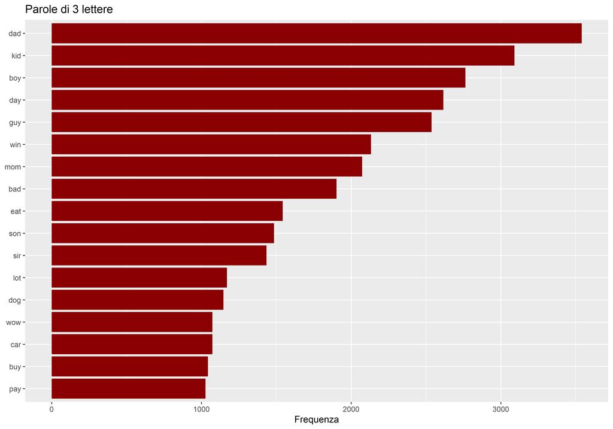

```r
# Parole di tre lettere (identifica rumori da rimuovere)
frequenze_simpson %>%
  filter(nchar(word) == 3) %>%
  filter(n > 1000) %>%
  mutate(word = reorder(word, n)) %>%
  ggplot(aes(word, n)) +
  geom_col(fill = "darkred") +
  coord_flip() +
  labs(title = "Parole di 3 lettere", x = NULL, y = "Frequenza")
```

Sulla base di queste osservazioni, si procede con la rimozione definitiva di termini troppo brevi o ripetitivi, ad eccezione di quelli ritenuti significativi nel contesto della serie (quali “tv” e “dr”).

```r
# Rimozione parole troppo corte o inutili
frequenze_simpson <- frequenze_simpson %>%
  filter(nchar(word) > 2 | word %in% c("tv", "dr"))
```

Infine, vengono riportati l’istogramma e il *wordcloud* delle parole più frequenti, in cui le prime cinque, non sorprendentemente, sono: “*dad*”, “*love*”, “*kid*”, “*boy*” e “*day*”.

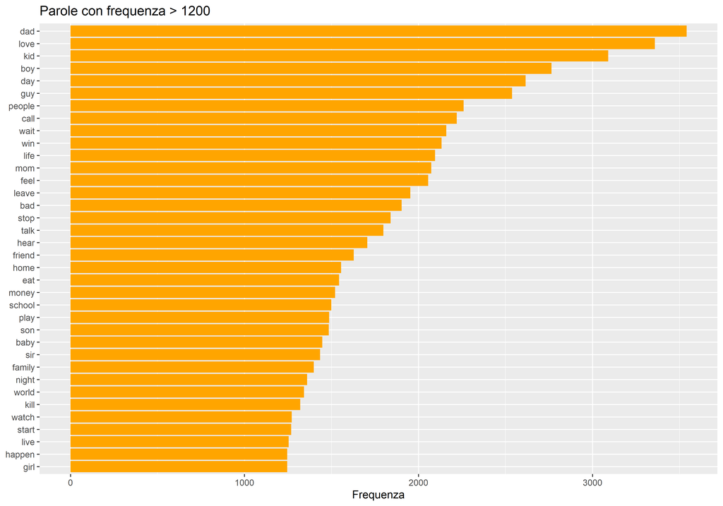

```r
# Parole con frequenza > 1200
frequenze_simpson %>%
  filter(n > 1200) %>%
  mutate(word = reorder(word, n)) %>%
  ggplot(aes(word, n)) +
  geom_col(fill = "orange") +
  coord_flip() +
  labs(title = "Parole con frequenza > 1200", x = NULL, y = "Frequenza")
```

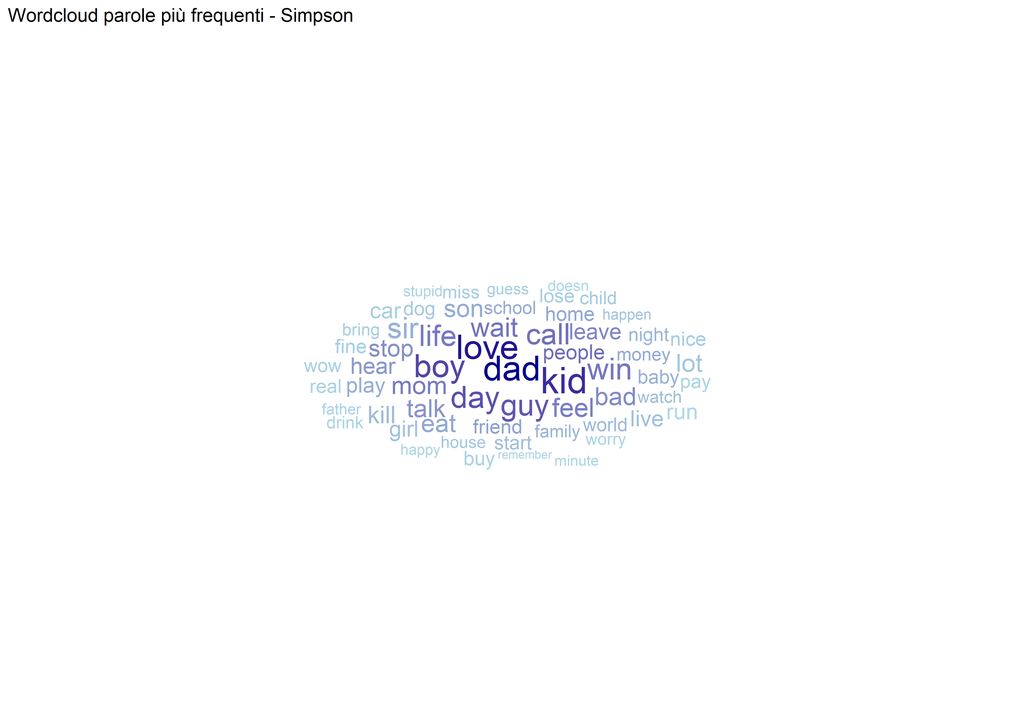

```r
# Wordcloud per le 60 parole più frequenti nei Simpson
frequenze_simpson %>%
  arrange(desc(n)) %>%
  slice_head(n = 60) %>%
  ggplot(aes(label = word, size = n, color = n)) +
  scale_color_gradient(low = "lightblue", high = "darkblue") +
  geom_text_wordcloud_area() +
  scale_size_area(max_size = 15) +
  labs(title = "Wordcloud parole più frequenti - Simpson") +
  theme_minimal()
```

### Analisi degli n-grammi ne *I Simpson* con *stopwords*

Si estraggono e contano le occorrenze di bigrammi, trigrammi e quadrigrammi. Poi si mostrano le dieci combinazioni più comuni per ciascun n-gramma. Sono state trovate strutture sintattiche frequenti, come forme verbali, incorrette a causa della lemmatizzazione, e che riflettono un linguaggio quotidiano e informale. Si osservano numerosi n-grammi che iniziano con “I”, evidenziando una forte presenza di dialoghi in prima persona, coerente con la struttura di uno *show* basato su interazioni familiari e personali.

```r
# Bigrammi più frequenti
bigrammi_simpson <- simpson %>%
  unnest_tokens(ngram, testo, token = "ngrams", n = 2) %>%
  count(ngram, sort = TRUE)
head(bigrammi_simpson, 10)
```

| ngram | n |
| --- | --- |
| i be | 17494 |
| it s | 9541 |
| i have | 7256 |
| you re | 7202 |
| i t | 6588 |
| that s | 6309 |
| be a | 5404 |
| i will | 4832 |
| in the | 4401 |
| you have | 3648 |

```r
# Trigrammi più frequenti
trigrammi_simpson <- simpson %>%
  unnest_tokens(ngram, testo, token = "ngrams", n = 3) %>%
  count(ngram, sort = TRUE)
head(trigrammi_simpson, 10)
```

| ngram | n |
| --- | --- |
| i be not | 1466 |
| it s a | 1158 |
| i be a | 1145 |
| i t know | 1134 |
| i be gonna | 1092 |
| what be you | 822 |
| i be sorry | 804 |
| it s not | 764 |
| and i be | 740 |
| i want to | 727 |

```r
# Quadrigrammi più frequenti
quadrigrammi_simpson <- simpson %>%
  unnest_tokens(ngram, testo, token = "ngrams", n = 4) %>%
  count(ngram, sort = TRUE)
head(quadrigrammi_simpson, 10)
```

| ngram | n |
| --- | --- |
| i be go to | 480 |
| what be you do | 361 |
| i have like to | 337 |
| i t want to | 286 |
| i want you to | 237 |
| i be sorry i | 228 |
| no no no no | 220 |
| i have get a | 204 |
| have oh have oh | 196 |
| we re go to | 181 |

```r
rm(bigrammi_simpson, trigrammi_simpson, quadrigrammi_simpson)
```

### Analisi delle frequenze ne *I Griffin*

Come ne *I Simpson*, si nota che la distribuzione delle frequenze è asimmetrica a destra.

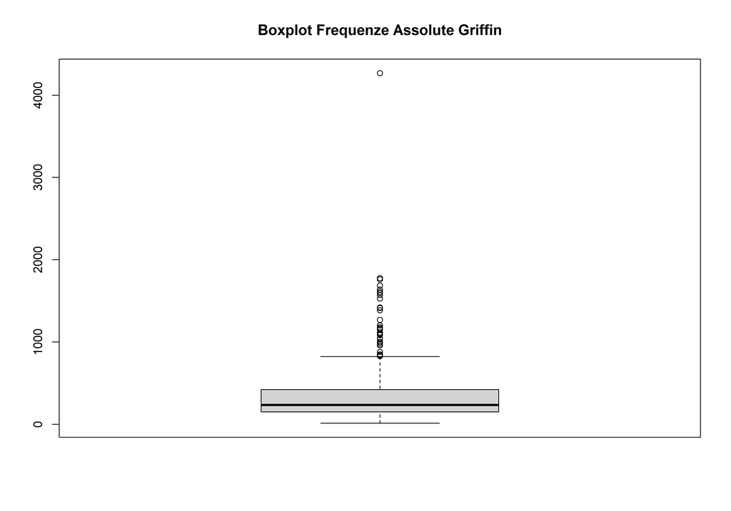

```r
## Analisi griffin
# Statistiche di base
frequenze_griffin %>% select(n) %>% boxplot(main = "Boxplot Frequenze Assolute Griffin")
```

E’ presente un *outlier* che compare oltre le 4000 volte (“guy”) e che viene rimosso, in quanto non informativo.

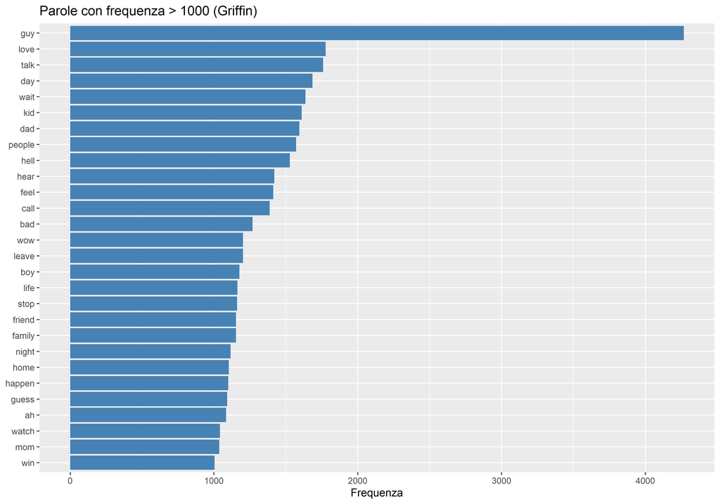

```r
# Parole con frequenza > 1000
frequenze_griffin %>%
  filter(n > 1000) %>%
  mutate(word = reorder(word, n)) %>%
  ggplot(aes(word, n)) +
  geom_col(fill = "steelblue") +
  coord_flip() +
  labs(title = "Parole con frequenza > 1000 (Griffin)", x = NULL, y = "Frequenza")
```

```r
# Rimozione outlier sopra soglia
frequenze_griffin <- frequenze_griffin %>%
  filter(n < 2000)
```

Di seguito si individuano parole poco informative o rumori, analizzando le parole di due o tre lettere. Vengono rimosse le parole con due caratteri, di nuovo ad eccezione di “tv” e “dr”.

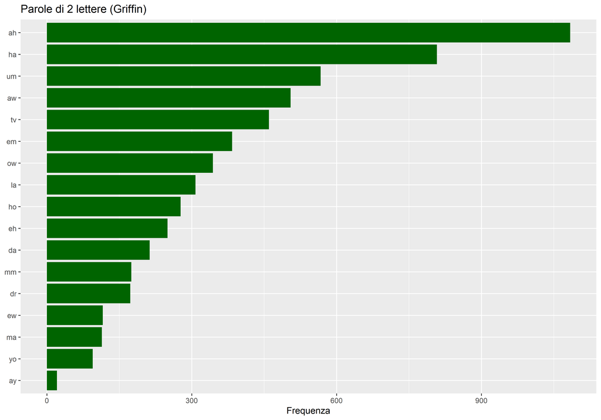

```r
# Parole di due lettere
frequenze_griffin %>%
  filter(nchar(word) == 2) %>%
  mutate(word = reorder(word, n)) %>%
  ggplot(aes(word, n)) +
  geom_col(fill = "darkgreen") +
  coord_flip() +
  labs(title = "Parole di 2 lettere (Griffin)", x = NULL, y = "Frequenza")
```

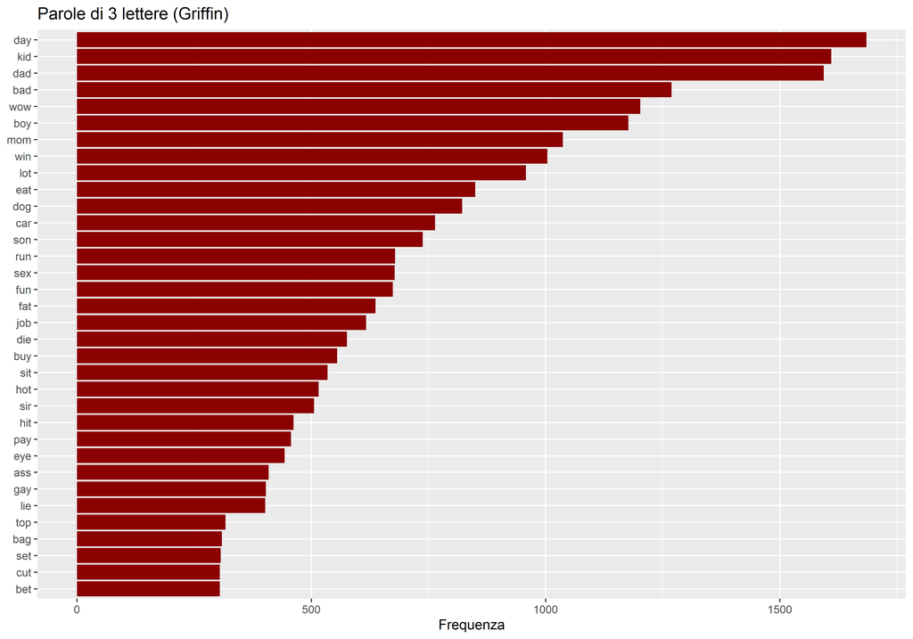

```r
# Parole di tre lettere
frequenze_griffin %>%
  filter(nchar(word) == 3) %>%
  filter(n > 300) %>%
  mutate(word = reorder(word, n)) %>%
  ggplot(aes(word, n)) +
  geom_col(fill = "darkred") +
  coord_flip() +
  labs(title = "Parole di 3 lettere (Griffin)", x = NULL, y = "Frequenza")
```

```r
# Rimozione parole brevi o inutili
frequenze_griffin <- frequenze_griffin %>%
  filter(nchar(word) > 2 | word %in% c("tv", "dr"))
```

Infine, vengono riportati l’istogramma e il *wordcloud* delle parole più frequenti, in cui le prime cinque sono: “love”, “talk”, “day”, “wait” e “kid”.

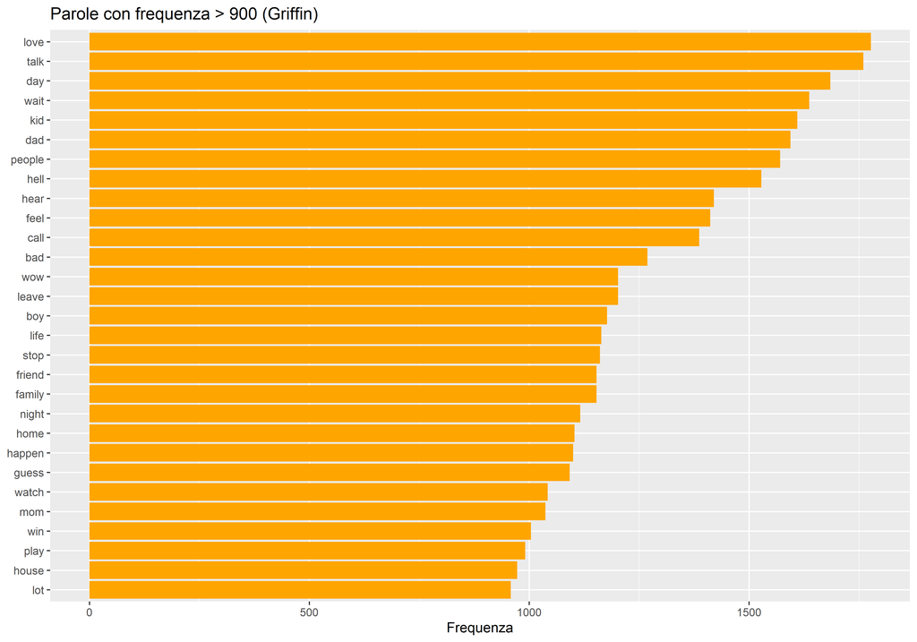

```r
# Parole con frequenza > 900
frequenze_griffin %>%
  filter(n > 900) %>%
  mutate(word = reorder(word, n)) %>%
  ggplot(aes(word, n)) +
  geom_col(fill = "orange") +
  coord_flip() +
  labs(title = "Parole con frequenza > 900 (Griffin)", x = NULL, y = "Frequenza")
```

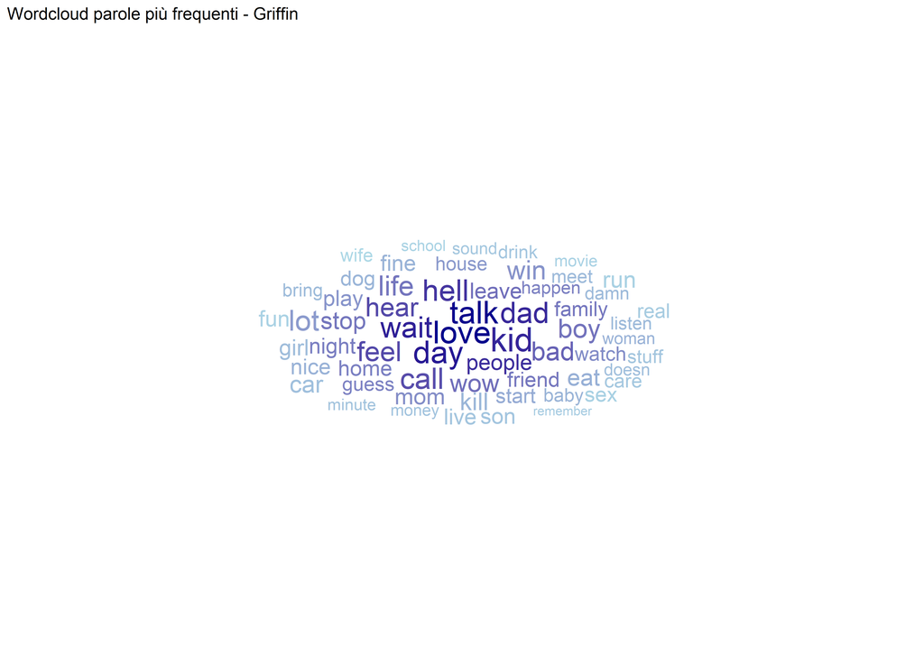

```r
# Wordcloud per le 60 parole più frequenti nei Griffin
frequenze_griffin %>%
  arrange(desc(n)) %>%
  slice_head(n = 60) %>%
  ggplot(aes(label = word, size = n, color = n)) +
  scale_color_gradient(low = "lightblue", high = "darkblue") +
  geom_text_wordcloud_area() +
  scale_size_area(max_size = 15) +
  labs(title = "Wordcloud parole più frequenti - Griffin") +
  theme_minimal()
```

### Analisi degli n-grammi ne *I Griffin* con *stopwords*

Si estraggono e contano le presenze di bigrammi, trigrammi e quadrigrammi. Poi si mostrano le dieci combinazioni più comuni per ciascun n-gramma. Come ne *I Simpson*, si denota un parlato fortemente colloquiale e un lessico molto centrato sull’azione e lo stato (si notino i verbi “essere”, “fare”..). Molti n-grammi ruotano intorno alla prima persona singolare. In aggiunta rispetto a *I Simpson*, sono presenti espressioni come “what the hell”, “oh my god” e “get out of here”, molto emotive ed enfatiche.

```r
# Bigrammi più frequenti
bigrammi_griffin <- griffin %>%
  unnest_tokens(ngram, testo, token = "ngrams", n = 2) %>%
  count(ngram, sort = TRUE)
head(bigrammi_griffin, 10)
```

| ngram | n |
| --- | --- |
| i be | 14561 |
| it s | 7667 |
| i t | 6049 |
| you re | 6045 |
| that s | 5542 |
| i have | 4792 |
| be a | 3917 |
| you know | 3441 |
| this be | 3323 |
| in the | 3227 |

```r
# Trigrammi più frequenti
trigrammi_griffin <- griffin %>%
  unnest_tokens(ngram, testo, token = "ngrams", n = 3) %>%
  count(ngram, sort = TRUE)
head(trigrammi_griffin, 10)
```

| ngram | n |
| --- | --- |
| oh my god | 1739 |
| i t know | 1408 |
| i be gonna | 1202 |
| i be not | 1149 |
| what be you | 1077 |
| what the hell | 935 |
| i be sorry | 844 |
| i be a | 812 |
| it s a | 805 |
| what do you | 787 |

```r
# Quadrigrammi più frequenti
quadrigrammi_griffin <- griffin %>%
  unnest_tokens(ngram, testo, token = "ngrams", n = 4) %>%
  count(ngram, sort = TRUE)
head(quadrigrammi_griffin, 10)
```

| ngram | n |
| --- | --- |
| what be you do | 507 |
| what the hell be | 403 |
| i be go to | 301 |
| what s go on | 291 |
| no no no no | 270 |
| i be sorry i | 246 |
| i t want to | 227 |
| get out of here | 226 |
| you know what i | 211 |
| be you talk about | 209 |

```r
rm(bigrammi_griffin, trigrammi_griffin, quadrigrammi_griffin)
```

### Analisi degli n-grammi senza *stopwords*

Rimuovendo le *stopwords*, non si trovano bigrammi e trigrammi rilevanti. Questa osservazione giustifica la scelta di non unirli in un unico *token*. Si può notare come vi siano spesso ripetizioni della stessa parola, interiezioni ed onomatopee. Queste ripetizioni sono tipiche di linguaggio parlato e *script* animati, dove il ritmo e l’espressività vocale sono fondamentali.

```r
# n- grammi senza stopwords simpson
# Bigrammi
# Simpson
bigrammi_simpson_sw <- simpson %>%
  select(testo) %>%
  unnest_tokens(ngram, testo, token = "ngrams", n = 2) %>%
  separate(ngram, into = c("word1", "word2"), sep = " ") %>%
  filter(!word1 %in% stop_words$word, !word2 %in% stop_words$word) %>%
  unite(ngram, word1, word2, sep = " ") %>%
  count(ngram, sort = TRUE)
bigrammi_simpson_sw %>% print(n = 15)
```

```
## # A tibble: 150,971 × 2
##    ngram           n
##    <chr>       <int>
##  1 mm hmm        417
##  2 hey hey       410
##  3 ha ha         398
##  4 whoa whoa     337
##  5 ow ow         323
##  6 whoo hoo      294
##  7 la la         246
##  8 hmm hmm       233
##  9 uh huh        229
## 10 wait wait     227
## 11 ice cream     198
## 12 homer homer   190
## 13 ho ho         184
## 14 uh uh         183
## 15 hey homer     175
## # ℹ 150,956 more rows
```

```r
# Griffin
bigrammi_griffin_sw <- griffin %>%
  select(testo) %>%
  unnest_tokens(ngram, testo, token = "ngrams", n = 2) %>%
  separate(ngram, into = c("word1", "word2"), sep = " ") %>%
  filter(!word1 %in% stop_words$word, !word2 %in% stop_words$word) %>%
  unite(ngram, word1, word2, sep = " ") %>%
  count(ngram, sort = TRUE)
bigrammi_griffin_sw %>% print(n = 15)
```

```
## # A tibble: 82,747 × 2
##    ngram          n
##    <chr>      <int>
##  1 ha ha        409
##  2 hey hey      277
##  3 whoa whoa    219
##  4 la la        218
##  5 hey guy      183
##  6 ho ho        169
##  7 hey lois     154
##  8 wait wait    136
##  9 family guy   134
## 10 hey peter    133
## 11 holy crap    133
## 12 bird bird    127
## 13 hey brian    126
## 14 da da        119
## 15 ow ow        116
## # ℹ 82,732 more rows
```

```r
# Trigrammi
# Simpson
trigrammi_simpson_sw <- simpson %>%
  select(testo) %>%
  unnest_tokens(ngram, testo, token = "ngrams", n = 3) %>%
  separate(ngram, into = c("word1", "word2", "word3"), sep = " ") %>%
  filter(!word1 %in% stop_words$word, !word2 %in% stop_words$word, !word3 %in% stop_words$word) %>%
  unite(ngram, word1, word2, word3, sep = " ") %>%
  count(ngram, sort = TRUE)
trigrammi_simpson_sw %>% print(n = 15)
```

```
## # A tibble: 73,230 × 2
##    ngram              n
##    <chr>          <int>
##  1 la la la         186
##  2 whoa whoa whoa   176
##  3 ow ow ow         173
##  4 â ã â            119
##  5 doo doo doo      103
##  6 hey hey hey      100
##  7 ha ha ha          98
##  8 â â ã             98
##  9 ã â â             97
## 10 ho ho ho          95
## 11 wait wait wait    89
## 12 da da da          79
## 13 bomp bomp bomp    74
## 14 bart bart bart    61
## 15 ba ba ba          60
## # ℹ 73,215 more rows
```

```r
# Griffin
trigrammi_griffin_sw <- griffin %>%
  select(testo) %>%
  unnest_tokens(ngram, testo, token = "ngrams", n = 3) %>%
  separate(ngram, into = c("word1", "word2", "word3"), sep = " ") %>%
  filter(!word1 %in% stop_words$word, !word2 %in% stop_words$word, !word3 %in% stop_words$word) %>%
  unite(ngram, word1, word2, word3, sep = " ") %>%
  count(ngram, sort = TRUE)
trigrammi_griffin_sw %>% print(n = 15)
```

```
## # A tibble: 36,716 × 2
##    ngram              n
##    <chr>          <int>
##  1 la la la         181
##  2 ha ha ha         178
##  3 whoa whoa whoa   113
##  4 ho ho ho          99
##  5 da da da          95
##  6 hey hey hey       73
##  7 ow ow ow          70
##  8 bird bird bird    65
##  9 num num num       50
## 10 wait wait wait    43
## 11 na na na          42
## 12 meg meg meg       41
## 13 duh duh duh       40
## 14 blah blah blah    31
## 15 bom bom bom       31
## # ℹ 36,701 more rows
```

```r
rm(bigrammi_simpson_sw, trigrammi_simpson_sw, bigrammi_griffin_sw, trigrammi_griffin_sw)
```

### Analisi comparativa

Sono stati confrontati i termini condivisi fra le due serie, ponendo attenzione sulle loro frequenze relative (calcolate rispetto al totale delle parole per ciascun *corpus*), per tenere conto della differenza del numero dei documenti tra i due *corpus.* Sono stati usati i dati senza i nomi dei personaggi, per generare dei risultati informativi e non triviali.

Si selezionano in `words_compare_f` le 100 parole più frequenti in entrambi i *set*, ordinandole sulla base della somma delle frequenze relative.

```r
# Rinomina colonne per evitare conflitti
frequenze_simpson <- frequenze_simpson %>% rename(freq_simpson = n)
frequenze_griffin <- frequenze_griffin %>% rename(freq_griffin = n)

# Inner join sulle parole comuni
words_compare <- inner_join(frequenze_simpson, frequenze_griffin, by = "word")

# Funzioni per normalizzare le frequenze relative
normalize_simpson <- function(x) (x/sum(frequenze_simpson$freq_simpson))

normalize_griffin <- function(x) (x/sum(frequenze_griffin$freq_griffin))

# Applica la normalizzazione ai dati uniti
words_compare_n <- words_compare %>%
  mutate(
    freq_simpson = normalize_simpson(freq_simpson),
    freq_griffin = normalize_griffin(freq_griffin)
  )
words_compare_n %>%
  mutate(across(where(is.numeric), ~ round(.x, 4))) %>%
  slice_head(n = 20)
```

| word | freq_simpson | freq_griffin |
| --- | --- | --- |
| dad | 0.0128 | 0.0090 |
| love | 0.0121 | 0.0100 |
| kid | 0.0112 | 0.0090 |
| boy | 0.0100 | 0.0066 |
| day | 0.0094 | 0.0095 |
| people | 0.0082 | 0.0088 |
| call | 0.0080 | 0.0078 |
| wait | 0.0078 | 0.0092 |
| win | 0.0077 | 0.0056 |
| life | 0.0076 | 0.0065 |

[output cut: 10 more lines]

```r
# Top 100 parole più frequenti in entrambi
words_compare_f <- words_compare_n %>%
  mutate(total = freq_simpson + freq_griffin) %>%
  slice_max(order_by = total, n = 100)
```

Il grafico mostra la distribuzione delle parole su scala logaritmica. Ogni punto rappresenta una parola, posizionata in base alla sua frequenza relativa ne *I Simpson* (asse x) e ne *I Griffin* (asse y). Di conseguenza, le parole al di sopra la linea rossa sono più usate ne *I Griffin*, quelle al di sotto, ne *I Simpson*. Le parole “dad”, “love” e “kid” sono fortemente usate in entrambi gli *show*, ma in particolare ne *I Simpson*. “Hell” e “damn” compaiono molto più spesso ne *I Griffin* rispetto a *I Simpson*, ad evidenziare il carattere più trasgressivo della serie.

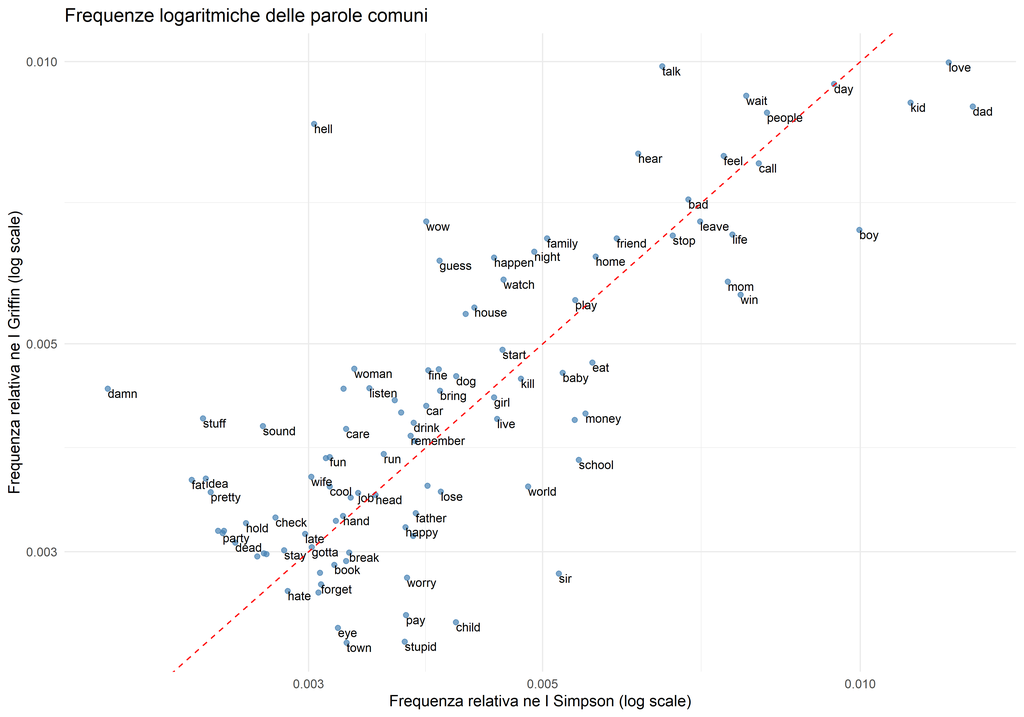

```r
# Grafico: scala logaritmica su tutte le parole
ggplot(words_compare_f, aes(x = freq_simpson, y = freq_griffin, label = word)) +
  geom_point(alpha = 0.7, color = "steelblue") +
  geom_text(check_overlap = TRUE, hjust = 0, vjust = 1, size = 3) +
  geom_abline(slope = 1, intercept = 0, color = "red", linetype = "dashed") +
  scale_x_log10() +  # scala logaritmica asse x
  scale_y_log10() +  # scala logaritmica asse y
  labs(
    title = "Frequenze logaritmiche delle parole comuni",
    x = "Frequenza relativa ne I Simpson (log scale)",
    y = "Frequenza relativa ne I Griffin (log scale)"
  ) +
  theme_minimal()
```

```r
#rm(words_compare, words_compare_f, words_compare_n, normalize)
```

L’analisi comparativa delle parole più frequenti tra le due serie è stata estesa tramite la libreria `quanteda`, che consente di identificare i termini più caratteristici di ciascuna serie.

Dopo aver unito i due *dataset* e costruito un *corpus*, si è proceduto alla *tokenizzazione* dei testi e alla creazione della *document-feature matrix* (DFM).

È stata calcolata la *keyness*, una misura basata sul test del chi-quadro, che quantifica quanto la frequenza osservata di un termine in un gruppo differisce da quella attesa rispetto a un gruppo di riferimento. In questo caso, il gruppo target è il corpus de *I Griffin*, quindi valori positivi indicano parole più rappresentative di questa serie, mentre valori negativi segnalano termini distintivi de *I Simpson*. Questo approccio consente di andare oltre le frequenze assolute, evidenziando differenze linguistiche e stilistiche rilevanti tra le due sitcom.

```r
# Aggiunge la colonna della serie
griffin_clean$serie <- "Griffin"
simpson_clean$serie <- "Simpson"

# Unisce i due dataset
corpus_data <- bind_rows(griffin_clean, simpson_clean)

# Crea un corpus quanteda
corp <- corpus(corpus_data, text_field = "testo")

# Tokenizza (i testi sono già lemmatizzati e puliti, quindi niente stopwords o stemming)
toks <- quanteda::tokens(corp)

# Crea la document-feature matrix (DFM)
dfm_all <- dfm(toks)

# Raggruppa per serie
dfm_grouped <- dfm_group(dfm_all, groups = docvars(dfm_all, "serie"))

# Calcola la keyness
result_keyness <- textstat_keyness(dfm_grouped, target = "Griffin")

# Visualizza i primi risultati
head(result_keyness, 10)
```

|  | feature | chi2 | p | n_target | n_reference |
| --- | --- | --- | --- | --- | --- |
| 1 | guy | 1524.3413 | 0 | 4268 | 2538 |
| 2 | quahog | 831.0017 | 0 | 547 | 0 |
| 3 | hell | 610.4890 | 0 | 1528 | 841 |
| 4 | sex | 494.9667 | 0 | 678 | 212 |
| 5 | bitch | 456.3048 | 0 | 410 | 55 |
| 6 | crap | 275.4339 | 0 | 537 | 244 |
| 7 | penis | 234.5771 | 0 | 192 | 18 |
| 8 | damn | 224.8169 | 0 | 797 | 536 |
| 9 | hang | 224.0174 | 0 | 591 | 336 |
| 10 | black | 209.5066 | 0 | 460 | 230 |

```r
tail(result_keyness, 10)
```

|  | feature | chi2 | p | n_target | n_reference |
| --- | --- | --- | --- | --- | --- |
| 619 | kent | -105.2570 | 0 | 27 | 252 |
| 620 | nuclear | -125.0251 | 0 | 19 | 258 |
| 621 | chief | -128.1126 | 0 | 64 | 396 |
| 622 | haw | -137.4968 | 0 | 13 | 257 |
| 623 | sir | -151.7826 | 0 | 506 | 1435 |
| 624 | plant | -161.2858 | 0 | 43 | 391 |
| 625 | boy | -161.3363 | 0 | 1177 | 2764 |
| 626 | dad | -163.4676 | 0 | 1594 | 3541 |
| 627 | whoo | -199.5578 | 0 | 62 | 510 |
| 628 | grampa | -298.8324 | 0 | 0 | 453 |

Nel grafico a barre sottostante vengono mostrate le 12 parole con i valori di chi-quadro più elevati a favore de *I Griffin* (blu) e le 12 più distintive a favore de *I Simpson* (giallo). L’asse x mostra la forza dell’associazione (valore della statistica test), mentre il colore distingue la serie di appartenenza.

Le parole con *keyness* più alta sono “guy”, già rimossa nelle frequenze in quanto non rilevante, e “Quahog”, la città dove sono ambientati *I Griffin*. Oltre a queste, i termini distintivi de *I Griffin* risultano più volgari e provocatori, coerenti con il tono irriverente dello *show*. Al contrario, le parole più tipiche de *I Simpson* sono generalmente più neutre o comuni, riflettendo un linguaggio più accessibile e adatto a un pubblico familiare. Questo risultato conferma empiricamente le differenze percepite tra le due serie.

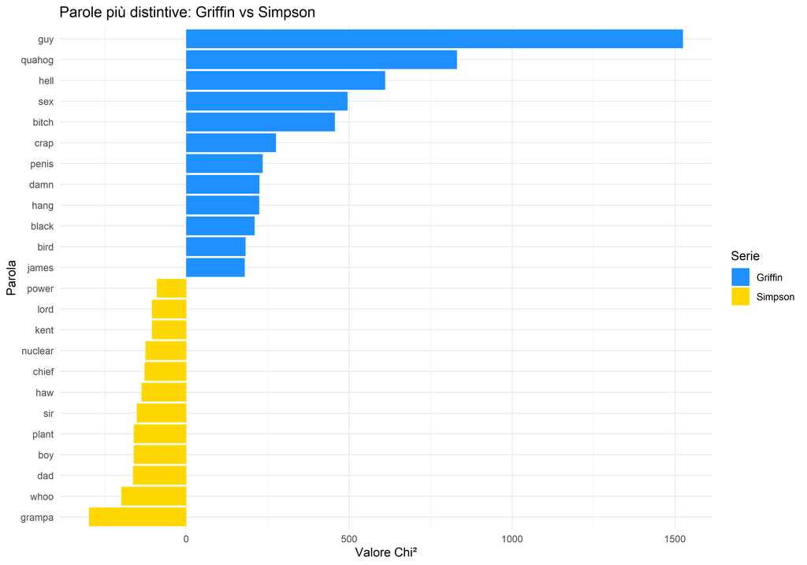

```r
# Seleziona le n parole più distintive per ciascun gruppo, per il grafico
n <- 12
{
  top_griffin <- result_keyness %>% filter(chi2 > 0) %>% slice_max(chi2, n = n)
  top_simpson <- result_keyness %>% filter(chi2 < 0) %>% slice_min(chi2, n = n)

  # Unisci i due insiemi
  top_words <- bind_rows(top_griffin, top_simpson)

  # Crea la variabile gruppo per colorare le barre
  top_words <- top_words %>%
    mutate(group = ifelse(chi2 > 0, "Griffin", "Simpson"))

  # Ordina i termini per plotting
  top_words <- top_words %>%
    mutate(feature = reorder(feature, chi2))
}

# Plot con ggplot2
ggplot(top_words, aes(x = feature, y = chi2, fill = group)) +
  geom_col(show.legend = TRUE) +
  coord_flip() +
  labs(title = "Parole più distintive: Griffin vs Simpson",
       x = "Parola",
       y = "Valore Chi²",
       fill = "Serie") +
  scale_fill_manual(values = c("Griffin" = "#1E90FF", "Simpson" = "#FFD700")) +
  theme_minimal()
```

### Parole più frequenti per stagione

Sono state confrontate le frequenze delle parole al variare delle stagioni di ogni serie, al fine di osservare come l’utilizzo del linguaggio (e la menzione dei personaggi) cambi nel tempo. Da notare che ora viene usato il *dataset* che comprende i nomi dei personaggi, che nel confronto fra stagioni può mostrare risultati interessanti.

Il grafico mostra, su scala logaritmica, le frequenze relative della stagione 1 (asse x) e stagione 36 (asse y), ossia la prima e l’ultima, de *I Simpson*. Le parole sulla diagonale sono rimaste invariate tra le due stagioni, quelle al di sopra di essa sono più frequenti nella stagione 36 e quelle al di sotto nella prima.

Nella prima stagione vengono menzionati più spesso i nomi dei personaggi principali, mentre nell’ultima spiccano, tra le altre: “ned”, “god” e “hate”.

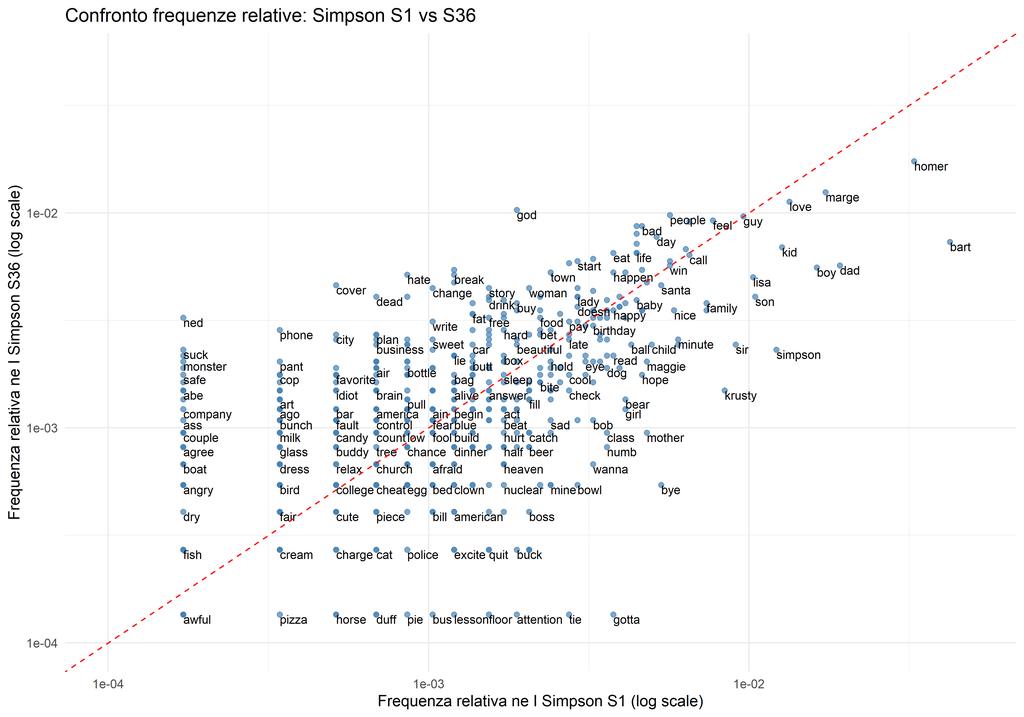

```r
# Parole più frequenti per stagione
# Calcolo frequenze relative per parola e stagione
frequenze_rel_simpson <- simpson_clean_2 %>%
  unnest_tokens(word, testo) %>%
  count(stagione, word) %>%
  group_by(stagione) %>%
  mutate(freq_rel = n / sum(n)) %>%
  ungroup()

# Seleziona parole comuni tra stagione 1 e stagione 36
words_compare_simpson <- inner_join(
  frequenze_rel_simpson %>% filter(stagione == 1),
  frequenze_rel_simpson %>% filter(stagione == 36),
  by = "word",
  suffix = c(".1", ".36")
)

# Grafico log-log con frequenze relative tra stagione 1 e stagione 36
ggplot(words_compare_simpson, aes(x = freq_rel.1, y = freq_rel.36, label = word)) +
  geom_point(alpha = 0.7, color = "steelblue") +
  geom_text(check_overlap = TRUE, hjust = 0, vjust = 1, size = 3) +
  geom_abline(slope = 1, intercept = 0, color = "red", linetype = "dashed") +
  scale_x_log10(limits=c(0.0001,0.05)) +
  scale_y_log10(limits=c(0.0001,0.05)) +
  labs(
    title = "Confronto frequenze relative: Simpson S1 vs S36",
    x = "Frequenza relativa ne I Simpson S1 (log scale)",
    y = "Frequenza relativa ne I Simpson S36 (log scale)"
  ) +
  theme_minimal()
```

Eseguendo la stessa analisi per stagioni contigue (decima e undicesima), si osservano variazioni linguistiche più contenute rispetto a quelle riscontrate nel confronto tra la prima e l’ultima stagione. Difatti, il grafico mostra che le frequenze delle parole risultano maggiormente concentrate lungo la diagonale.

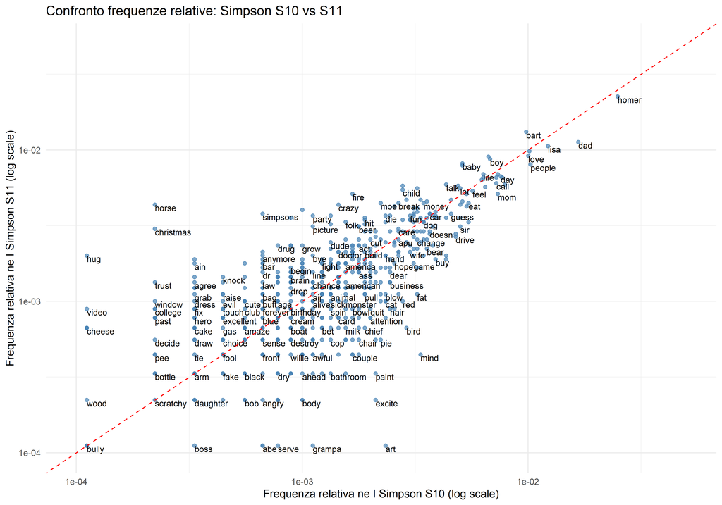

```r
# Seleziona parole comuni tra stagione 10 e stagione 11
words_compare_simpson_2 <- inner_join(
  frequenze_rel_simpson %>% filter(stagione == 10),
  frequenze_rel_simpson %>% filter(stagione == 11),
  by = "word",
  suffix = c(".10", ".11")
)

# Grafico log-log con frequenze relative tra stagioni 10 e 11
ggplot(words_compare_simpson_2, aes(x = freq_rel.10, y = freq_rel.11, label = word)) +
  geom_point(alpha = 0.7, color = "steelblue") +
  geom_text(check_overlap = TRUE, hjust = 0, vjust = 1, size = 3) +
  geom_abline(slope = 1, intercept = 0, color = "red", linetype = "dashed") +
  scale_x_log10(limits=c(0.0001,0.05)) +
  scale_y_log10(limits=c(0.0001,0.05)) +
  labs(
    title = "Confronto frequenze relative: Simpson S10 vs S11",
    x = "Frequenza relativa ne I Simpson S10 (log scale)",
    y = "Frequenza relativa ne I Simpson S11 (log scale)"
  ) +
  theme_minimal()
```

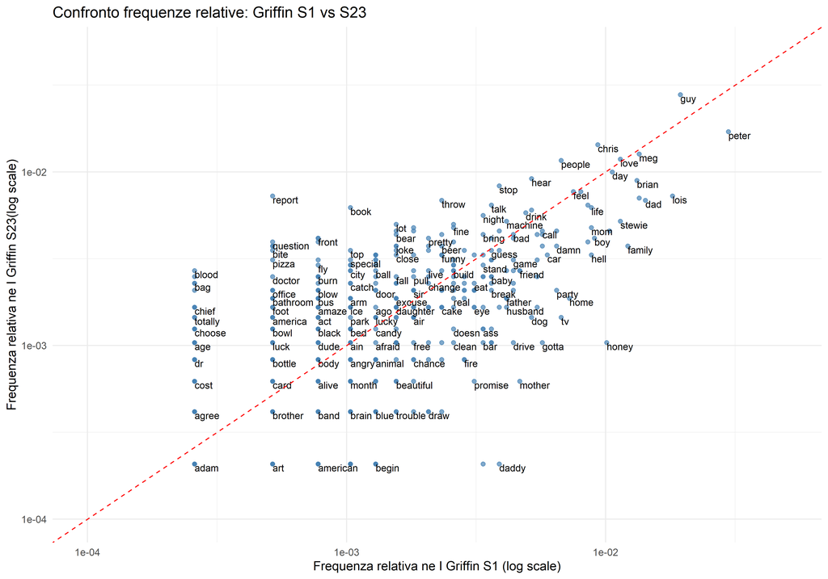

```r
# Griffin
# Calcolo frequenze relative per parola e stagione
frequenze_rel_griffin <- griffin_clean_2 %>%
  unnest_tokens(word, testo) %>%
  count(stagione, word) %>%
  group_by(stagione) %>%
  mutate(freq_rel = n / sum(n)) %>%
  ungroup()

# Seleziona parole comuni tra stagione 1 e stagione 23
words_compare_griffin <- inner_join(
  frequenze_rel_griffin %>% filter(stagione == 1),
  frequenze_rel_griffin %>% filter(stagione == 23),
  by = "word",
  suffix = c(".1", ".23")
)

# Grafico log-log con frequenze relative
ggplot(words_compare_griffin, aes(x = freq_rel.1, y = freq_rel.23, label = word)) +
  geom_point(alpha = 0.7, color = "steelblue") +
  geom_text(check_overlap = TRUE, hjust = 0, vjust = 1, size = 3) +
  geom_abline(slope = 1, intercept = 0, color = "red", linetype = "dashed") +
  scale_x_log10(limits=c(0.0001,0.05)) +
  scale_y_log10(limits=c(0.0001,0.05)) +
  labs(
    title = "Confronto frequenze relative: Griffin S1 vs S23",
    x = "Frequenza relativa ne I Griffin S1 (log scale)",
    y = "Frequenza relativa ne I Griffin S23(log scale)"
  ) +
  theme_minimal()
```

```r
rm(words_compare_griffin, top_words_griffin)
```

Come per *I Simpson*, l’analisi su due stagioni consecutive (anche qui, 10 e 11) mostra parole più concentrare sulla diagonale.

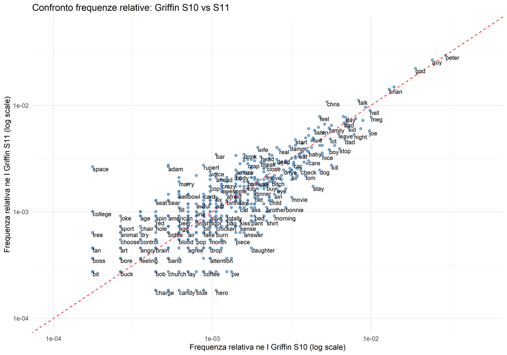

```r
# Seleziona parole comuni tra stagione 10 e stagione 11
words_compare_griffin_2 <- inner_join(
  frequenze_rel_griffin %>% filter(stagione == 10),
  frequenze_rel_griffin %>% filter(stagione == 11),
  by = "word",
  suffix = c(".10", ".11")
)

# Grafico log-log con frequenze relative
ggplot(words_compare_griffin_2, aes(x = freq_rel.10, y = freq_rel.11, label = word)) +
  geom_point(alpha = 0.7, color = "steelblue") +
  geom_text(check_overlap = TRUE, hjust = 0, vjust = 1, size = 3) +
  geom_abline(slope = 1, intercept = 0, color = "red", linetype = "dashed") +
  scale_x_log10(limits=c(0.0001,0.05)) +
  scale_y_log10(limits=c(0.0001,0.05)) +
  labs(
    title = "Confronto frequenze relative: Griffin S10 vs S11",
    x = "Frequenza relativa ne I Griffin S10 (log scale)",
    y = "Frequenza relativa ne I Griffin S11 (log scale)"
  ) +
  theme_minimal()
```

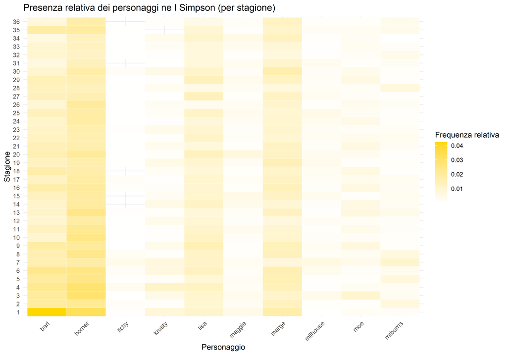

```r
# Lista dei personaggi di interesse
simpson_heatmap <- c("homer", "bart", "marge", "lisa", "maggie",
                "moe", "milhouse", "krusty", "mrburns", "patty", "itchy")

# Filtra solo le parole corrispondenti ai personaggi
heatmap_simpson_personaggi <- frequenze_rel_simpson %>%
  filter(word %in% simpson_heatmap)

# Crea la heatmap
ggplot(heatmap_simpson_personaggi, aes(x = word, y = factor(stagione), fill = freq_rel)) +
  geom_tile(color = "white") +
  scale_fill_gradient(low = "white", high = "#FFD700", name = "Frequenza relativa") +
  labs(
    title = "Presenza relativa dei personaggi ne I Simpson (per stagione)",
    x = "Personaggio",
    y = "Stagione"
  ) +
  theme_minimal() +
  theme(axis.text.x = element_text(angle = 45, hjust = 1))
```

Ne *I Griffin*, Peter è il personaggio più presente e stabile in tutte le stagioni, con particolare intensità nelle prime seguita da una leggera diminuzione negli ultimi anni. Stewie mostra un aumento nelle ultime stagioni; Brian e Lois al contrario sono più nominati nelle prime. Interessante l’andamento delle menzioni della città di Cleveland, che sembra diminuire intorno alle stagioni 9-11, lo stesso periodo in cui è stato creato il suo *show* indipendente “The Cleveland Show” (2009-2013).

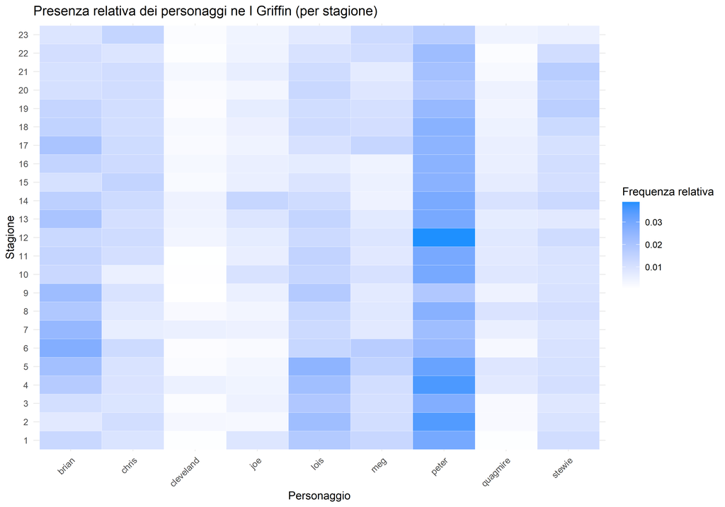

```r
# Lista dei personaggi di interesse
griffin_heatmap <- c("peter","meg","brian","lois","stewie","chris","quagmire","cleveland","joe")

# Filtra solo le parole corrispondenti ai personaggi
heatmap_griffin_personaggi <- frequenze_rel_griffin %>%
  filter(word %in% griffin_heatmap)

# Crea la heatmap
ggplot(heatmap_griffin_personaggi, aes(x = word, y = factor(stagione), fill = freq_rel)) +
  geom_tile(color = "white") +
  scale_fill_gradient(low = "white", high = "#1E90FF", name = "Frequenza relativa") +
  labs(
    title = "Presenza relativa dei personaggi ne I Griffin (per stagione)",
    x = "Personaggio",
    y = "Stagione"
  ) +
  theme_minimal() +
  theme(axis.text.x = element_text(angle = 45, hjust=1))
```

### Associazioni

Per studiare le associazioni tra parole è necessario disporre di una *Document-Term Matrix*, in cui ogni riga corrisponde a un episodio e ogni colonna a un termine, con il valore che indica la frequenza del termine nel documento.

In questo passaggio vengono create le DTM per entrambe le serie, sia nella versione completa (in cui sono presenti anche i nomi dei personaggi), sia in quella epurata dai nomi propri. Per alleggerire la lettura, la funzione `create_dtm()` è riportata in Appendice D.

```r
# Creazione DTM
#senza personaggi
dtm_s_all <- create_dtm(simpson_clean, stop_words$word, 'S')
dtm_g_all <- create_dtm(griffin_clean, stop_words$word, 'G')

#con personaggi
dtm_s     <- create_dtm(simpson_clean_2, c(stop_words$word, stopwords_nostre), 'S')
dtm_g     <- create_dtm(griffin_clean_2, c(stop_words$word, stopwords_nostre), 'G')
```

Viene utilizzata la funzione `findAssocs` per identificare co-occorrenze notevoli tra i vari termini, con diverse soglie di correlazione (0.3 e 0.2). Si può notare chiaramente che le associazioni più rilevanti per il termine “beer” ne *I Griffin* fanno riferimento a personaggi appartenenti a *I Simpson* (“Smithers”, “Nelson”, “Sprigfield”…); questo perché c’è un episodio in particolare (S13 Ep01), il cui titolo è “E alla fine si incontrano”, dove si riuniscono le famiglie di entrambe le serie.

```r
# Cerca associazioni
#SIMPSON
findAssocs(dtm_s_all, "beer", 0.3)
```

```
## $beer
##  duff drink
##  0.53  0.42
```

```r
findAssocs(dtm_s, "beer", 0.3)
```

```
## $beer
##  duff drink
##  0.53  0.42
```

```r
findAssocs(dtm_s_all, "homer", 0.3)
```

```
## $homer
## numeric(0)
```

```r
#GRIFFIN
findAssocs(dtm_g_all, "beer", 0.2)
```

```
## $beer
## drink  duff   wee  boss
##  0.26  0.23  0.21  0.20
```

```r
findAssocs(dtm_g, "beer", 0.2)
```

```
## $beer
##       drink    smithers      nelson springfield         apu        duff
##        0.26        0.26        0.24        0.23        0.23        0.23
##    flanders      krusty       marge         moe     skinner       homer
##        0.23        0.23        0.23        0.23        0.23        0.22
##        bart        boss
##        0.21        0.20
```

```r
findAssocs(dtm_g_all, "peter", 0.3)
```

```
## $peter
## numeric(0)
```

Ad ogni modo, un’analisi delle associazioni tramite `findAssocs` non è opportuna in questa situazione: difatti, la ricerca delle associazioni si svolge all’interno del medesimo documento. Ma la co-occorrenza di due parole nello stesso episodio non implica un legame stretto tra di esse, a causa della vastità di parole e temi che possono caratterizzare un singolo episodio. Viene quindi scritta una funzione al fine di segmentare il testo: i “documenti” diventano ora delle finestre mobili di 80 parole, che scorrono il testo con passo di 40 parole. Si è cercato, con questa procedura, di rendere più “locale” la ricerca delle associazioni, e quindi meno spuria la natura delle stesse. Va da sé che parametri diversi per la segmentazione del testo portano a risultati differenti, ma si è provato ad identificare, tramite *trial-and-error*, dei valori che portassero a conclusioni apprezzabili. Successivamente viene costruita una DTM basata sui nuovi documenti, ovvero i segmenti. Infine, si definisce un vettore di parole per ogni serie, sui quali cui può essere interessante ricercare le associazioni.

```r
# Segmentazione del testo in finestre sovrapposte (sliding window)
segmenta_testo_sliding <- function(testo, finestra = 80, passo = 40) {
  parole <- unlist(tokenize_words(testo))
  n <- length(parole)
  # Crea segmenti di 'finestra' parole, facendo scorrere la finestra di 'passo' parole alla volta
  segmenti <- lapply(seq(1, n - finestra + 1, by = passo), function(i) {
    paste(parole[i:(i + finestra - 1)], collapse = " ")
  })
  return(segmenti)
}

# Segmentazione e creazione DTM
crea_dtm_segmenti <- function(df) {
  df_seg <- df %>%
    # Rimuove numeri
    mutate(testo = str_remove_all(testo, "\\d+")) %>%
    # Applica la segmentazione per ogni riga (episodio)
    rowwise() %>%
    mutate(segmenti = list(segmenta_testo_sliding(testo))) %>%
    # Espande la lista di segmenti: una riga per ogni segmento
    unnest(segmenti) %>%
    mutate(segmento_id = row_number()) %>%
    ungroup()
  # Crea un corpus di testi a partire dai segmenti
  corpus <- VCorpus(VectorSource(df_seg$segmenti))
  rm(df_seg)
  gc()
  return(DocumentTermMatrix(corpus))
}

# DTM segmentato per cercare associazioni
dtm_s_s <- crea_dtm_segmenti(simpson_clean_2)
dtm_g_s <- crea_dtm_segmenti(griffin_clean_2)

# Lista di parole interessanti
specifiche_s <- c(
  "homer", "bart", "marge", "lisa", "mr", "moe", "ned", "krusty", "milhouse",
  "apu", "wiggum", "skinner", "flanders", "smithers", "maggie", "patty",
  "selma", "grandpa", "springfield", "kwik", "plant", "tavern", "duff",
  "krustyburger", "leftorium", "donut", "doh", "excellent", "hidely-ho",
  "nuclear", "mayor", "church"
)

specifiche_g <- c(
  "peter", "lois", "stewie", "brian", "quagmire", "cleveland", "meg", "chris",
  "chicken", "fight", "flashback", "cutaway", "television", "death", "dog",
  "baby", "alcohol", "joe"
)

generiche <- c(
  "school", "job", "work", "family", "money", "love", "problem", "beer", "hate",
  "funny", "stupid", "crazy", "help", "home", "bar", "election", "environment",
  "holiday", "halloween", "drink", "eat", "sleep", "dream", "argue", "laugh",
  "friend", "neighbor", "boss", "student", "teacher", "marriage", "parent",
  "child", "brother", "sister", "enemy", "competition", "angry", "happy", "sad",
  "jealous", "proud", "embarrassed", "smart", "dumb", "genius", "success",
  "failure", "god", "tv", "show", "italy", "plan", "joke", "memory", "battle",
  "friendship", "kill", "sex"
)

parole_interessanti_s <- c(specifiche_s, generiche)
parole_interessanti_g <- c(specifiche_g, generiche)
```

Viene poi implementata una funzione per automatizzare la ricerca delle associazioni tra parole nelle DTM dei segmenti. In questo caso il risultato più interessante sembra essere l’associazione tra i termini “gay” e “marriage” ne *I Griffin*; gli altri risultati sembrano nuovamente abbastanza scontati se non superflui. È quantomeno simpatica l’associazione tra “drink” e “liver” ne *I Griffin*; infine, l’associazione tra “dove” e “boss” è dovuta alla singola comparsa della parola “dove” in un contesto lavorativo, e la si può ritenere un’associazione non degna di interesse.

```r
# Trova associazioni con soglia minima
trova_associazioni <- function(dtm, parole, corlimit = 0.25) {
  assoc_list <- list()
  # Cicla su tutte le parole di interesse
  for (i in seq_along(parole)) {
    parola <- parole[i]
    # cat(sprintf("'%s', parola %d/%d \n", parola, i, length(parole)))
    if (parola %in% Terms(dtm)) {
      assoc <- findAssocs(dtm, parola, corlimit)
      # Se sono state trovate associazioni, le aggiunge alla lista
      if (length(assoc[[1]]) > 0) assoc_list[[parola]] <- assoc[[1]]
    }
  }
  return(assoc_list)
}

#Estrai le associazioni interessanti
associazioni_s <- trova_associazioni(dtm_s_s, parole_interessanti_s, corlimit = 0.25)
associazioni_g <- trova_associazioni(dtm_g_s, parole_interessanti_g, corlimit = 0.25)

associazioni_s
```

```
## $ned
## flanders
##     0.42
##
## $krusty
## clown
##  0.41
##
## $flanders
##  ned
## 0.42
##
## $smithers
## mrburns     sir
##    0.42    0.36
##
## $springfield
## town
## 0.29
##
## $plant
## nuclear
##    0.42
##
## $duff
## beer
## 0.31
##
## $nuclear
## plant
##  0.42
##
## $school
## student
##    0.26
##
## $beer
## duff
## 0.31
##
## $student
## school
##   0.26
```

```r
associazioni_g
```

```
## $peter
## lois
##  0.3
##
## $lois
## peter
##   0.3
##
## $joe
## bonnie
##   0.26
##
## $school
## student
##     0.3
##
## $drink
## liver
##   0.3
##
## $boss
## dove
##  0.3
##
## $student
## school
##    0.3
##
## $marriage
##  gay
## 0.31
```

## *Latent Dirichlet Allocation* (LDA)

Una volta costruite le *Document-Term Matrix* (DTM) per le singole serie e per la combinazione delle due, si è proceduto con un’analisi dei *topic* tramite il modello LDA (*Latent Dirichlet Allocation*), con l’obiettivo di individuare le tematiche latenti ricorrenti nei dialoghi. Inizialmente, il numero ottimale di *topic* è stato stimato tramite metriche diagnostiche (coerenza semantica, divergenza tra i *topic*, *log-likelihood*); tuttavia, per una migliore interpretabilità dei risultati, è stato adottato un criterio più soggettivo, basato sull’analisi dei termini più rappresentativi e sulla coerenza semantica interna di ciascun gruppo.

Successivamente, per migliorare l’interpretabilità dei *topic*, sono stati assegnati dei titoli indicativi a ciascuno di essi. A supporto di questa fase, si è fatto ricorso ai riassunti degli episodi disponibili su IMDb, che hanno permesso di contestualizzare meglio i contenuti sottostanti ai singoli *topic* e di verificarne la corrispondenza narrativa.

```r
# DTM
dtm_s = create_dtm(simpson_clean, prefix = 'S')
dtm_g = create_dtm(griffin_clean, prefix = 'G')
dtm_s2 = create_dtm(simpson_clean_2, prefix = 'S')
dtm_g2 = create_dtm(griffin_clean_2, prefix = 'G')

# Aggiungi il prefisso e unisci
simpson_clean <- simpson_clean %>% mutate(prefix = "S")
griffin_clean <- griffin_clean %>% mutate(prefix = "G")
dati_dtm_tot <- bind_rows(simpson_clean, griffin_clean)

simpson_clean_2 <- simpson_clean_2 %>% mutate(prefix = "S")
griffin_clean_2 <- griffin_clean_2 %>% mutate(prefix = "G")
dati_dtm_tot2 <- bind_rows(simpson_clean_2, griffin_clean_2)

# Crea le DTM combinate
dtm_tot <- create_dtm(dati_dtm_tot)
dtm_tot2 <- create_dtm(dati_dtm_tot2)
```

### Analisi LDA delle serie combinate

Attraverso il codice in Appendice D, viene effettuata una valutazione tramite quattro metriche diagnostiche per la scelta del numero *k* di *topic* ottimale. Sebbene le metriche suggeriscano circa 20/25 *topic*, i contenuti degli stessi sembrano ripetersi, perciò un’analisi qualitativa approfondita delle parole chiave e della coerenza semantica ha condotto alla decisione di adottare un modello con 9 *topic*. Tale scelta è stata adottata per bilanciare l’interpretabilità dei diversi gruppi. I *topic* con i nomi dei personaggi sono più caratterizzati da alcune personalità specifiche (es. Homer e la birra, Lisa e la scuola, ecc…).

```r
# Carico direttamente i dati, costruiti con la funzione in appendice
#load("LDA_k.RData")
#load("LDA_k2.RData")

# Definizione dei titoli dei topic (senza personaggi)
titoli_senza_personaggi <- c(
  "Famiglia",
  "Episodi natalizi",
  "Relazioni sociali",
  "Cronaca",
  "Amore e relazioni",
  "Scuola",
  "Tempo libero",
  "Conversazioni",
  "Lavoro e denaro"
)

# Definizione dei titoli dei topic (con i personaggi)
titoli_con_personaggi <- c(
  "Cronaca",
  "Griffin",
  "Famiglia",
  "Amore e relazioni",
  "Vita quotidiana",
  "Tempo libero",
  "Scuola",
  "Lavoro e denaro",
  "Simpson"
)

lda_results <- analyze_lda_titolati_table(lda_k, lda_k2, k = 9, n_top_terms = 15,
                                          custom_titles_1 = titoli_senza_personaggi,
                                          custom_titles_2 = titoli_con_personaggi)
```

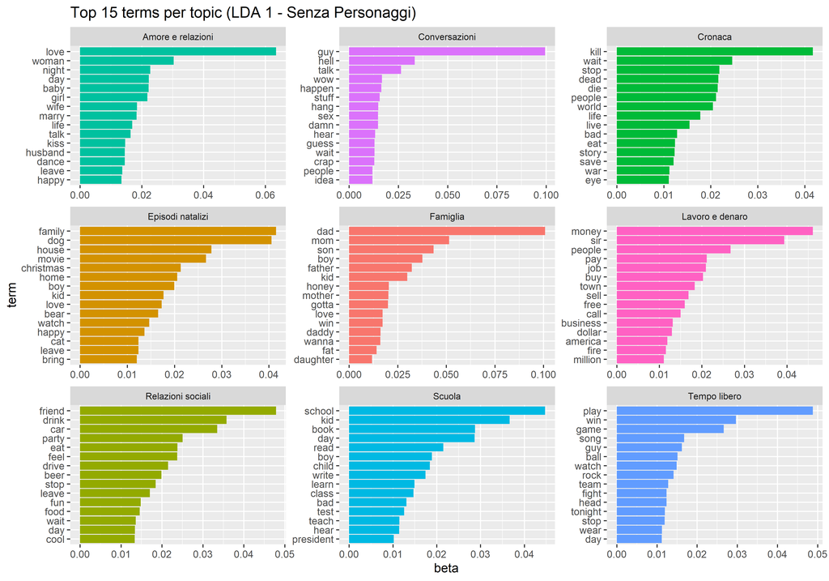

[figure not shown]

Distribuzione dei documenti per topic - LDA 1 (Senza Personaggi)

|  | Tempo libero | Amore e relazioni | Conversazioni | Cronaca | Episodi natalizi | Famiglia | Lavoro e denaro | Relazioni sociali | Scuola |
| --- | --- | --- | --- | --- | --- | --- | --- | --- | --- |
| G | 31 | 37 | 233 | 23 | 31 | 25 | 8 | 25 | 26 |
| S | 67 | 107 | 10 | 109 | 78 | 105 | 123 | 77 | 119 |

Distribuzione dei documenti per topic - LDA 2 (Con Personaggi)

|  | Vita quotidiana | Amore e relazioni | Cronaca | Famiglia | Griffin | Lavoro e denaro | Scuola | Simpson | Tempo libero |
| --- | --- | --- | --- | --- | --- | --- | --- | --- | --- |
| G | 10 | 13 | 16 | 6 | 365 | 6 | 4 | 0 | 14 |
| S | 55 | 76 | 81 | 68 | 0 | 83 | 163 | 209 | 56 |

### Analisi LDA per *I Simpson*

Anche per i soli *Simpson*, le diagnostiche suggerivano 20/25 *topic*, ma un’analisi qualitativa ha evidenziato maggiore chiarezza con 7 *topic*.

Tra gli altri, il *topic* “Televisione e intrattenimento” è stato nominato così in quanto caratterizzato da termini quali “movie”, “Krusty”, “tv”, “watch” e “book”, che richiamano contenuti mediali. Inoltre, il *topic* “Conversazioni” contiene termini discorsivi. Tra le parole contenute in “Homer e tempo libero” si trova *kill*, e si suppone sia dovuto ai continui litigi e strangolamenti di Homer e Bart.

```r
#
#load("lda_k_s.RData")
#load("lda_k_s2.RData")

# Definizione dei titoli dei topic (senza personaggi)
titoli_senza_personaggi_simpson <- c(
 "Fede e morte",
 "Amore e relazioni",
 "Lavoro e denaro",
 "Episodi natalizi",
 "Famiglia",
 "Scuola",
 "Amicizia e tempo libero"
)


# Definizione dei titoli dei topic (con i personaggi)
titoli_con_personaggi_simpson <- c(
 "Conversazioni",
 "Lisa e scuola",
 "Homer e Marge",
 "Bart",
 "Televisione e intrattenimento",
 "Homer e lavoro",
 "Homer e tempo libero"
)

lda_results_s <- analyze_lda_serie_titolati(lda_k_s, lda_k_s2, k = 7, serie_nome = 'Simpson',
                                          n_top_terms = 15,
                                          custom_titles_1 = titoli_senza_personaggi_simpson,
                                          custom_titles_2 = titoli_con_personaggi_simpson)
```

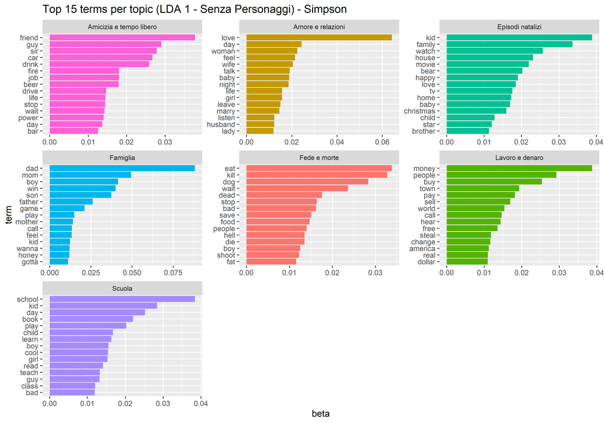

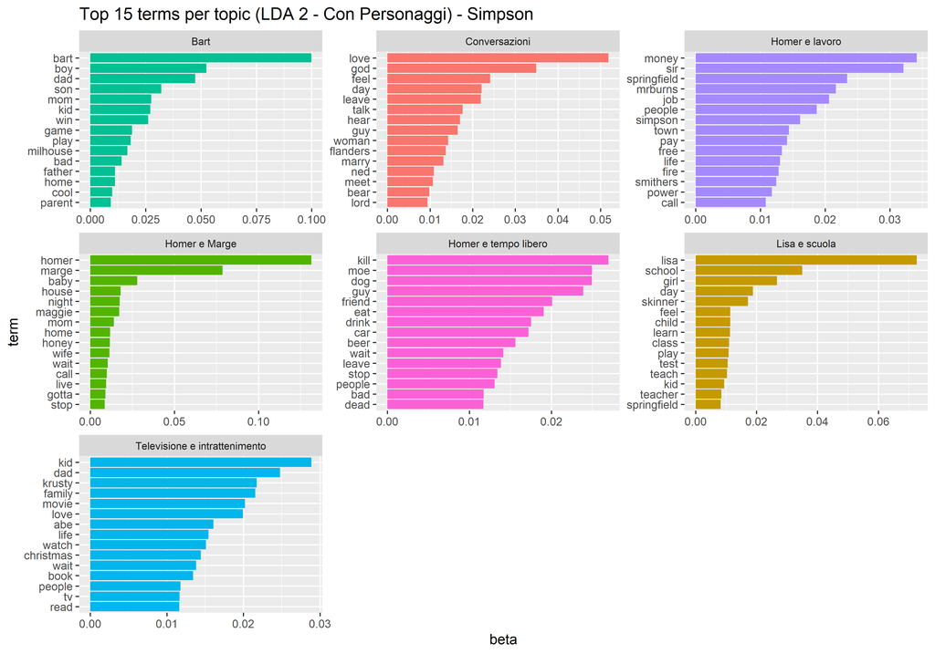

### Analisi LDA per *I Griffin*

Per *i Griffin*, 15 *topic* sono considerati un buon numero secondo le diagnostiche, suggerendo una minore complessità tematica rispetto ai Simpson. Ciò emergeva anche dalla minor eterogeneità tra le stagioni, evidenziata nel capitolo di *Text mining*. Comunque, anche in questo caso, sono stati considerati meno *topic*, ritenendo 5 la scelta ottimale. Può sembrare strano il *topic* “Violenza” dal momento che è presente il termine “Christmas”, ma ciò è dovuto ad un episodio in cui Stewie and Brian decidono di andare al Polo Nord per “dare una lezione a Babbo Natale”, come si può leggere nel riassunto ottenuto da IMDb. Inoltre, parole come *kill*, *hell* e *damn* riflettono i toni aggressivi della serie.

```r
# Carico direttamente i dati, costruiti con la funzione in appendice(dove è stata modificata la dtm in uso)
#load("LDA_k_g.RData")
#load("LDA_k_g2.RData")

# Definizione dei titoli dei topic (senza personaggi)
titoli_senza_personaggi_griffin <- c(
 "Famiglia",
 "Società e news",
 "Relazioni",
 "Tempo libero",
 "Violenza"
)


# Definizione dei titoli dei topic (con i personaggi)
titoli_con_personaggi_griffin <- c(
 "Personaggi secondari",
 "Peter e Lois",
 "Famiglia",
 "Media e società",
 "Brian e Stewie"
)

lda_results_g <- analyze_lda_serie_titolati(lda_k_g, lda_k_g2, k = 5, serie_nome = 'Griffin', n_top_terms = 15, custom_titles_1 = titoli_senza_personaggi_griffin, custom_titles_2 = titoli_con_personaggi_griffin)
```

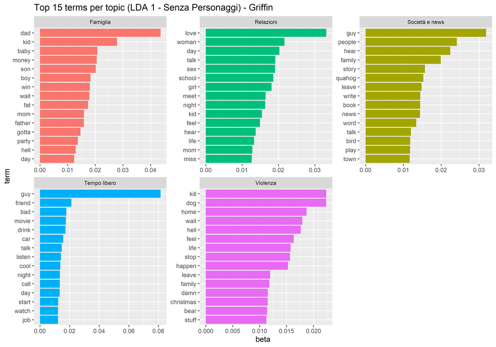

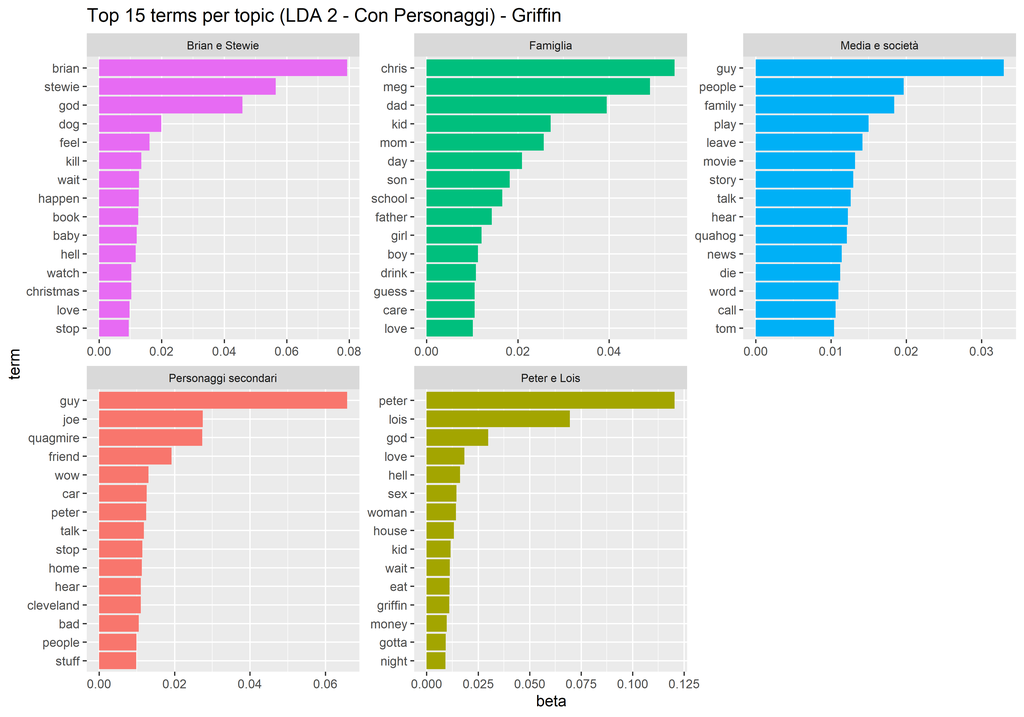

#### Analisi degli episodi più significativi di ogni *topic*

```r
#creo id documento su imdb
imdb$doc_id <- paste0(imdb$serie,"_S", ifelse(imdb$stagione < 10, paste0("0", imdb$stagione), imdb$stagione),
                      "_E", ifelse(imdb$episodio < 10, paste0("0", imdb$episodio), imdb$episodio))

# Unione dei risultati LDA con i riassunti IMDb
# topics_1 no personaggi
# topics_2 si personaggi
lda_imdb_g <- lda_results_g$topics_1 %>% inner_join(imdb, by = c("document" = "doc_id"))
lda_imdb_s <- lda_results_s$topics_1 %>% inner_join(imdb, by = c("document" = "doc_id"))

# guardo i riassunti per ogni gruppo
# scegliere il topic
lda_imdb_g %>% filter(topic == 5) %>% arrange(desc(gamma)) %>% select(riassunto) %>% print(n=8)
```

```
## # A tibble: 80 × 1
##   riassunto
##   <chr>
## 1 Stewie and Brian go back in time to stop Bertram from killing Leonardo da Vin…
## 2 Disappointed with the Mall Santa, Stewie and Brian decide to go up to the Nor…
## 3 Peter fills Carter with the spirit of Christmas. Meanwhile, Stewie goes back …
## 4 Meg adopts a cat that Brian believes is evil.
## 5 Meg gets a surprising response when she takes Stewie to meet Santa at the mal…
## 6 The Griffins must save Christmas without Lois when she walks out on them for …
## 7 Holiday mishaps include Lois going ballistic after losing her Christmas cheer…
## 8 Stewie e Brian tornano indietro nel tempo fino gennaio 31 del 1999, provocand…
## # ℹ 72 more rows
```

```r
lda_imdb_s %>% filter(topic == 4) %>% arrange(desc(gamma)) %>% select(riassunto) %>% print(n=8)
```

```
## # A tibble: 90 × 1
##   riassunto
##   <chr>
## 1 Marge is determined to fix Christmas following a failed Black Friday shopping…
## 2 After spending all his money on an expensive gift for himself, and the family…
## 3 Homer tells the tale of the first Christmas ever, while Grandpa pursues his d…
## 4 After his birthday party goes wrong, Mr. Burns begins to want his childhood t…
## 5 Krusty hides out at a circus after he nearly kills Homer, who becomes a TV re…
## 6 When a sudden tourist spike means that the family cannot afford Christmas, th…
## 7 A cable channel films a Christmas movie in Springfield and Skinner falls in l…
## 8 Marge gets depressed when the rest of the family does not get into the holida…
## # ℹ 82 more rows
```

## *Structural Topic Modeling*

Passiamo ora alla modellazione tramite STM (*Structural Topic Modeling*), che rispetto alla LDA appena presentata permette di includere anche l’effetto di alcune covariate nell’assegnazione degli episodi ai vari *topic*.

Inizializziamo alcuni vettori o matrici di variabili di cui indagheremo l’effetto per mezzo del *topic modeling* con STM. Le variabili sono: i presidenti degli Stati Uniti, l’anno di produzione della singola stagione ed i produttori delle rispettive serie. Si noti che per questi ultimi è necessario codificare una matrice di variabili indicatrici, data la saltuaria collaborazione tra produttori in stagioni differenti.

```r
# Creazione df adatto con covariate ####
tot_clean <- bind_rows(simpson_clean, griffin_clean)

# simpson = 0, griffin = 1
tot_clean$serie = c(rep("S", 784), rep("G", 432))

anno = c(1989:2024, 1999, 1999, 2001, 2005:2024)
# numero di episodi per stagione
epi_per_stag = c(
  rle(simpson_clean$stagione)$lengths,
  rle(griffin_clean$stagione)$lengths
)

# per ogni episodio, l'anno corrispondente
tot_clean$anni = rep(anno, epi_per_stag)

presidenti <- tibble(anno = 1989:2025,
                     presidente = c(
                       rep('George H.W. Bush', 4),
                       rep('Bill Clinton', 8),
                       rep('George W. Bush', 8),
                       rep('Barack Obama', 8),
                       rep('Donald Trump', 4),
                       rep('Joe Biden', 4),
                       'Donald Trump'))

tot_clean <- tot_clean %>% left_join(presidenti, by = c("anni" = "anno"))

produttori = matrix(NA, 1216, 13)
colnames(produttori) = c(
  'Groening_Brooks_Simon',
  'Jean',
  'Reiss',
  'Mirkin',
  'Oakley_Weinstein',
  'Scully',
  'MacFarlane_Zuckerman',
  'Palladino',
  'Goodman_Sheridan',
  'Hentemann',
  'Callaghan',
  'Sulkin',
  'Appel'
)

somma = function(x,y){
  return((cumsum(epi_per_stag[1:x])[x]+1):cumsum(epi_per_stag[1:y])[y])
}

# matrice dei produttori, dove 1 se presente, 0 altrimenti
produttori[1:sum(epi_per_stag[1:2]), 1] = 1
produttori[somma(2,4), 2:3] = 1
produttori[somma(4,6), 4] = 1
produttori[somma(6,8), 5] = 1
produttori[somma(8,12), 6] = 1
produttori[somma(10,36), 2] = 1
produttori[somma(36,39), 7] = 1
produttori[somma(38,39), 8] = 1
produttori[somma(39,43), 9] = 1
produttori[somma(43,46), 10] = 1
produttori[somma(43,51), 11] = 1
produttori[c(somma(46,49),somma(51,59)), 12] = 1
produttori[somma(49,59), 13] = 1

produttori <- as_tibble(produttori)

produttori = ifelse(is.na(produttori), 0, 1)

tot_clean <- bind_cols(tot_clean, produttori)

tot_clean$doc_id <- paste0(tot_clean$serie,
                           "_S", ifelse(tot_clean$stagione < 10, paste0("0", tot_clean$stagione), tot_clean$stagione),
                           "_E", ifelse(tot_clean$episodio < 10, paste0("0", tot_clean$episodio), tot_clean$episodio))

tot_clean_processed <- textProcessor(documents = tot_clean$testo, metadata = tot_clean)
tot_clean_out <- prepDocuments(tot_clean_processed$documents, tot_clean_processed$vocab, tot_clean_processed$meta)

tot_clean_out$meta$serie <- as.factor(tot_clean_out$meta$serie)
```

Distinguendo tra le due serie, si nota chiaramente il linguaggio più provocatorio e adulto che utilizzano *I Griffin*, come si è gia notato più volte.

Si noti come si è deciso di utilizzare come variabile di *content* la serie di appartenenza degli episodi, perché si è ipotizzato che fosse la variabile che più influenza la scelta delle parole all’interno dei *topic*. Questa scelta fa sì che i *topic* non vengano definiti solo sulla base delle differenze linguistiche tra le serie, in modo da riflettere strutture concettuali condivise. Il focus, difatti, è posto ad un livello più alto dei singoli vocaboli, in questo *setting*.

```r
# anno ####
stm_anni <- stm(documents = tot_clean_out$documents,
                  vocab = tot_clean_out$vocab,
                  data = tot_clean_out$meta,
                  K = 9,
                  prevalence = ~ anni,
                  content = ~ serie)
```

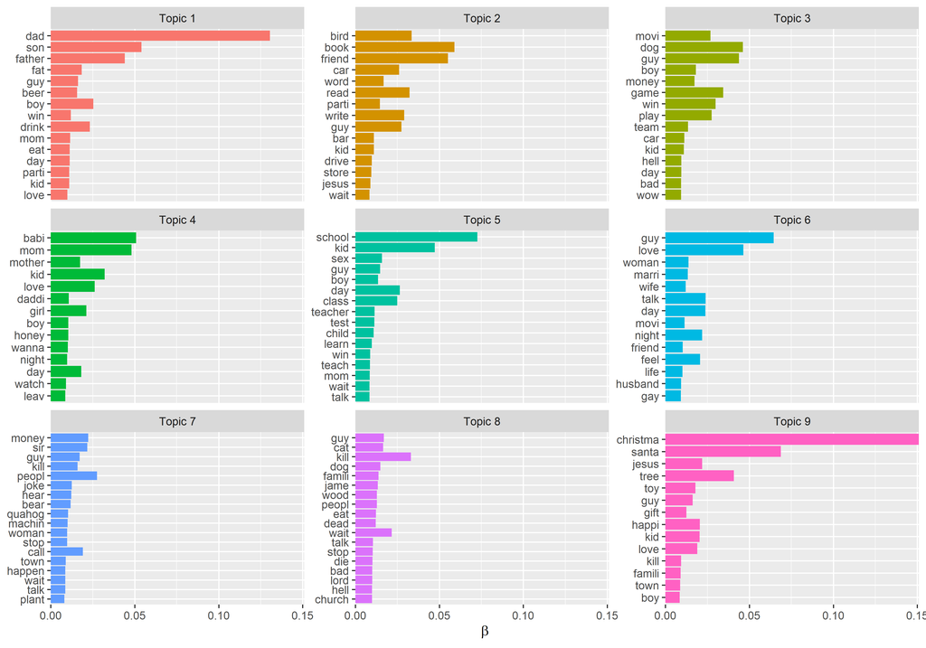

```r
# Distribuzione parola-topic ####
stm_anni_topics <- tidy(stm_anni, matrix = "beta")

# Crea il grafico delle prime 20 parole per topic
stm_anni_topics %>%
  group_by(topic) %>%
  slice_max(beta, n = 20) %>%
  ungroup() %>%
  mutate(topic = paste("Topic", topic)) %>%
  ggplot(aes(beta, reorder_within(term, beta, topic), fill = topic)) +
  geom_col(show.legend = FALSE) +
  facet_wrap(vars(topic), scales = "free_y") +
  scale_x_continuous(expand = c(0, 0)) +
  scale_y_reordered() +
  labs(x = expression(beta), y = NULL)
```

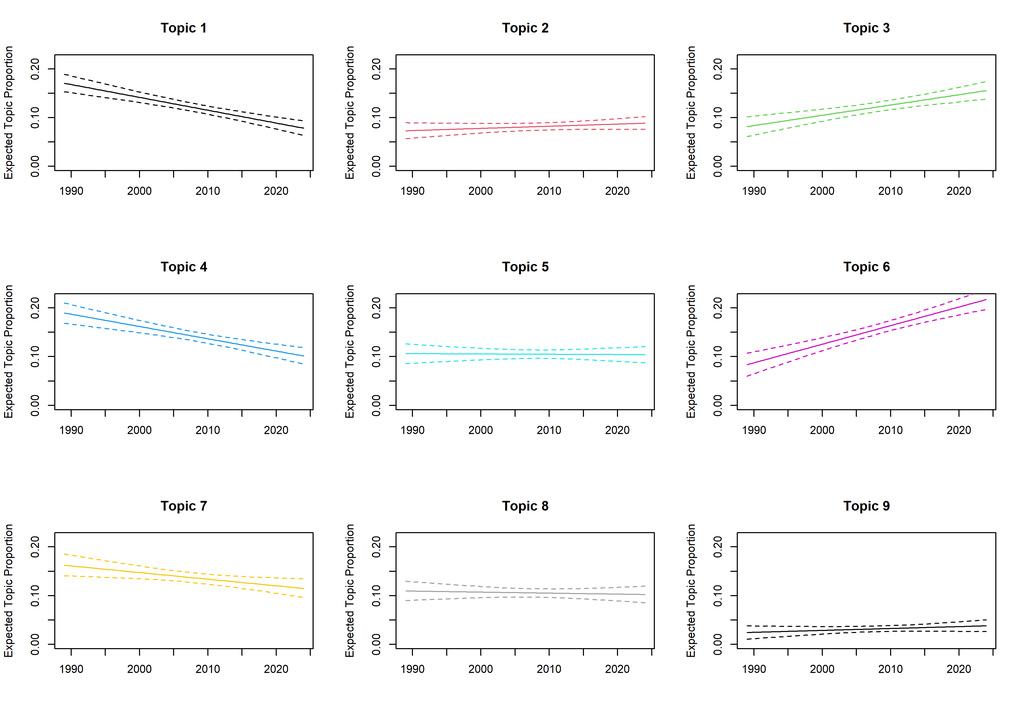

```r
effect_anni <- estimateEffect(1:9 ~ anni, stmobj = stm_anni, metadata = tot_clean_out$meta)
#summary(effect_anni)

par(mfrow = c(3,3))
for(i in 1:9){
  plot(effect_anni, covariate = "anni", method = "continuous", topics = i, ylim = c(0, 0.22), linecol = i, printlegend = F, main=paste0("Topic ", i))
}
```

Si ripete la stessa analisi utilizzando i presidenti degli Stati Uniti come covariata, con la consapevolezza che `anni` e `presidenti` siano variabili fortemente correlate. Questa seconda strada vuole indagare in modo più approfondito le possibili influenze tra il contesto socio-economico dovuto ad una particolare presidenza e l’eventuale effetto di queste sulle serie tv in oggetto. Si noti come le parole più frequenti nei vari *topic* sono qualitativamente equivalenti a quelle ottenute nel modello precedente. Si manterranno dunque le nomenclature presentate precedentemente.

```r
# Presidente ####
tot_clean_out$meta$presidente = factor(tot_clean_out$meta$presidente,
                                       levels = c("George H.W. Bush", "Bill Clinton",
                                                  "George W. Bush", "Barack Obama",
                                                  "Donald Trump", "Joe Biden"))

stm_presidente <- stm(documents = tot_clean_out$documents,
                        vocab = tot_clean_out$vocab,
                        data = tot_clean_out$meta,
                        K = 9,  # numero di topic
                        prevalence = ~ -1 + presidente,
                        content = ~ serie)
```

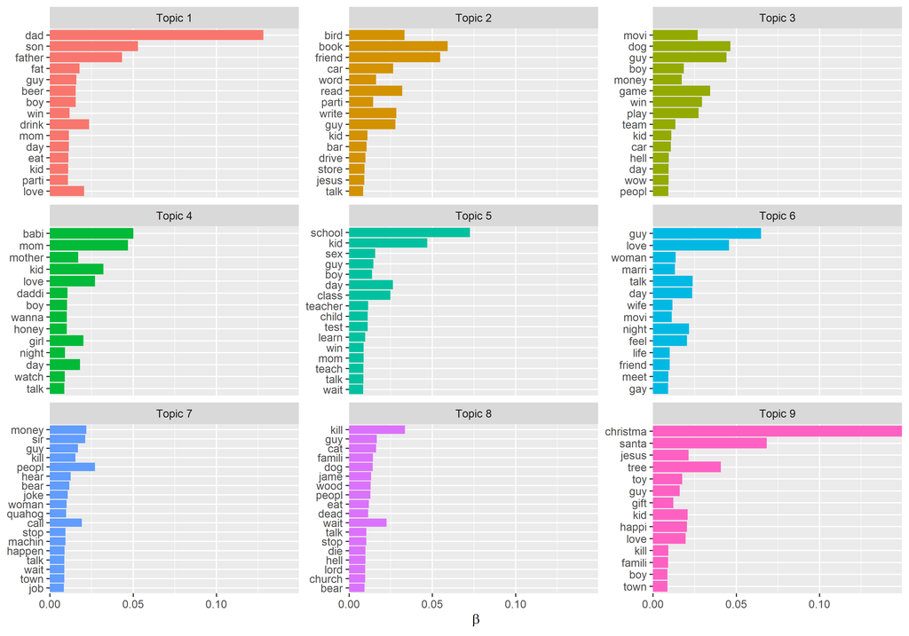

```r
# Distribuzione parola-topic) ####
stm_presidente_topics <- tidy(stm_presidente, matrix = "beta")

# Crea il grafico delle prime 20 parole per topic
stm_presidente_topics %>%
  group_by(topic) %>%
  slice_max(beta, n = 20) %>%
  ungroup() %>%
  mutate(topic = paste("Topic", topic)) %>%
  ggplot(aes(beta, reorder_within(term, beta, topic), fill = topic)) +
  geom_col(show.legend = FALSE) +
  facet_wrap(vars(topic), scales = "free_y") +
  scale_x_continuous(expand = c(0, 0)) +
  scale_y_reordered() +
  labs(x = expression(beta), y = NULL)
```

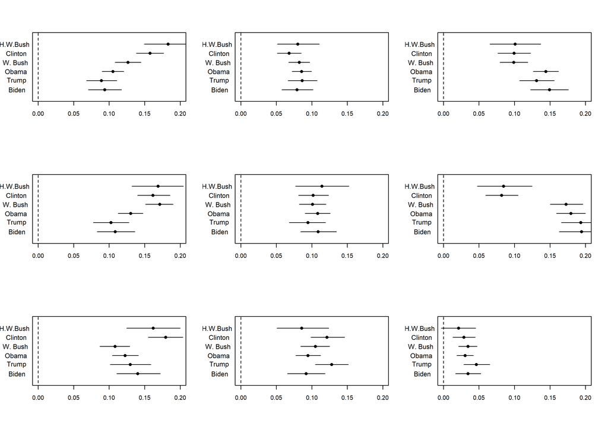

```r
effect_presidente <- estimateEffect(1:9 ~ -1 + presidente, stmobj = stm_presidente, metadata = tot_clean_out$meta )

par(mfrow = c(3,3))
for(i in 1:9){
  plot(effect_presidente, covariate = "presidente", method = "pointestimate", topics = i,
       labeltype = 'custom', custom.labels = "",
       cex.lab = 0.9, cex = 0.9, cex.axis = 0.9, xlim = c(0, 0.2))
  text(-0.025, seq(6, 1, by = -1),
       labels = c("H.W.Bush", "Clinton", "W. Bush", "Obama","Trump", "Biden"),
       xpd = T, adj=0.7)
}
```